# Assessment of In Silico Tools for Variant Effect Prediction in Haemoglobinopathies

```r
  "MVP",
  "Missense predictor",
  "MVP_score_new",
  NA_character_,
  "continuous score",
  "Higher score = more pathogenic",
  NA_real_,
  "Threshold to document",
  TRUE,
  FALSE,
  "Coverage and descriptive analysis first",

  "MPC",
  "Missense predictor",
  "MPC_score_new",
  NA_character_,
  "continuous score",
  "Higher score = more pathogenic",
  NA_real_,
  "Threshold to document",
  TRUE,
  FALSE,
  "Coverage and descriptive analysis first",

  "gMVP",
  "Missense predictor",
  "gMVP_score_new",
  NA_character_,
  "continuous score",
  "Higher score = more pathogenic",
  NA_real_,
  "Threshold to document",
  TRUE,
  FALSE,
  "Coverage and descriptive analysis first",

  "VEST4",
  "Missense predictor",
  "VEST4_score_seperated",
  NA_character_,
  "continuous score",
  "Higher score = more pathogenic",
  NA_real_,
  "Threshold to document",
  TRUE,
  FALSE,
  "Original score column available",

  "Condel",
  "Meta-predictor",
  "Condel_score",
  NA_character_,
  "continuous score",
  "Higher score = more pathogenic",
  NA_real_,
  "Threshold to document",
  TRUE,
  FALSE,
  "Original score column available",

  # ---------------------------------------------------------------------------
  # Newer missense and protein-language-model predictors
  # ---------------------------------------------------------------------------

  "AlphaMissense",
  "Missense predictor",
  "am_pathogenicity_new",
  "am_class_new",
  "score + prediction",
  "Higher score = more pathogenic",
  NA_real_,
  "Tool class label",
  TRUE,
  TRUE,
  "Check missense-only coverage carefully",

  "EVE",
  "Missense/evolutionary model",
  "EVE_SCORE_new",
  "EVE_CLASS_new",
  "score + prediction",
  "Higher score = more pathogenic",
  NA_real_,
  "Tool class label",
  TRUE,
  TRUE,
  "Check missense-only coverage carefully",

  "ESM1b",
  "Protein language model predictor",
  "ESM1b_score_new",
  "ESM1b_pred_new",
  "score + prediction",
  "Score direction requires confirmation",
  NA_real_,
  "Tool/dbNSFP prediction label",
  TRUE,
  TRUE,
  "Updated dbNSFP score and prediction available",

  "popEVE",
  "Population-adjusted evolutionary model",
  "popEVE_SCORE_1_new",
  "popEVE_pred_new",
  "score + prediction",
  "Score direction requires confirmation",
  NA_real_,
  "Tool/dbNSFP prediction label",
  TRUE,
  TRUE,
  "Updated popEVE score and prediction available",

  # ---------------------------------------------------------------------------
  # Splicing predictors
  # ---------------------------------------------------------------------------

  "SpliceAI",
  "Splicing predictor",
  "SpliceAI_DS",
  NA_character_,
  "continuous score",
  "Higher score = stronger splice impact",
  NA_real_,
  "SpliceAI threshold to document",
  TRUE,
  FALSE,
  "Original SpliceAI summary score available",

  "SpliceAI acceptor gain",
  "Splicing predictor",
  "SpliceAI_pred_DS_AG_new",
  NA_character_,
  "continuous score",
  "Higher score = stronger splice impact",
  NA_real_,
  "SpliceAI threshold to document",
  TRUE,
  FALSE,
  "Updated SpliceAI delta score",

  "SpliceAI acceptor loss",
  "Splicing predictor",
  "SpliceAI_pred_DS_AL_new",
  NA_character_,
  "continuous score",
  "Higher score = stronger splice impact",
  NA_real_,
  "SpliceAI threshold to document",
  TRUE,
  FALSE,
  "Updated SpliceAI delta score",

  "SpliceAI donor gain",
  "Splicing predictor",
  "SpliceAI_pred_DS_DG_new",
  NA_character_,
  "continuous score",
  "Higher score = stronger splice impact",
  NA_real_,
  "SpliceAI threshold to document",
  TRUE,
  FALSE,
  "Updated SpliceAI delta score",

  "SpliceAI donor loss",
  "Splicing predictor",
  "SpliceAI_pred_DS_DL_new",
  NA_character_,
  "continuous score",
  "Higher score = stronger splice impact",
  NA_real_,
  "SpliceAI threshold to document",
  TRUE,
  FALSE,
  "Updated SpliceAI delta score",

  "MaxEntScan",
  "Splicing predictor",
  "MaxEntScan_diff_new",
  NA_character_,
  "continuous score",
  "Direction depends on score definition",
  NA_real_,
  "Threshold to document",
  TRUE,
  FALSE,
  "Splicing-specific descriptive and coverage analysis",

  "ada_score",
  "Splicing predictor",
  "ada_score_new",
  NA_character_,
  "continuous score",
  "Higher score = stronger splice impact",
  NA_real_,
  "Threshold to document",
  TRUE,
  FALSE,
  "Splicing-specific descriptive and coverage analysis",

  "rf_score",
  "Splicing predictor",
  "rf_score_new",
  NA_character_,
  "continuous score",
  "Higher score = stronger splice impact",
  NA_real_,
  "Threshold to document",
  TRUE,
  FALSE,
  "Splicing-specific descriptive and coverage analysis",

  # ---------------------------------------------------------------------------
  # Conservation and constraint scores
  # ---------------------------------------------------------------------------

  "GERP++",
  "Conservation score",
  "GERP__RS_new",
  NA_character_,
  "continuous score",
  "Higher score = more conserved or constrained",
  NA_real_,
  "Not a direct pathogenicity threshold",
  TRUE,
  FALSE,
  "Use for coverage and descriptive analysis, not the main binary benchmark",

  "phyloP100way",
  "Conservation score",
  "phyloP100way_vertebrate_new",
  NA_character_,
  "continuous score",
  "Higher score = more conserved",
  NA_real_,
  "Not a direct pathogenicity threshold",
  TRUE,
  FALSE,
  "Use for coverage and descriptive analysis",

  "phastCons100way",
  "Conservation score",
  "phastCons100way_vertebrate_new",
  NA_character_,
  "continuous score",
  "Higher score = more conserved",
  NA_real_,
  "Not a direct pathogenicity threshold",
  TRUE,
  FALSE,
  "Use for coverage and descriptive analysis",

  "SiPhy",
  "Conservation score",
  "SiPhy_29way_logOdds",
  NA_character_,
  "continuous score",
  "Higher score = more conserved",
  NA_real_,
  "Not a direct pathogenicity threshold",
  TRUE,
  FALSE,
  "Original score column available",

  "BLOSUM62",
  "Amino-acid substitution/conservation score",
  "BLOSUM62_new",
  NA_character_,
  "continuous score",
  "Lower scores usually indicate a less tolerated substitution",
  NA_real_,
  "Not a direct pathogenicity threshold",
  TRUE,
  FALSE,
  "Use cautiously; not a standalone pathogenicity predictor"
)
```

```r
# -----------------------------------------------------------------------------
# Validate the structure of the reference table
# -----------------------------------------------------------------------------

expected_columns <- c(
  "tool",
  "tool_classification",
  "score_column",
  "prediction_column",
  "score_type",
  "score_direction",
  "default_threshold",
  "threshold_source",
  "include_in_coverage",
  "include_in_binary_analysis",
  "notes"
)

missing_columns <- setdiff(
  expected_columns,
  names(tool_reference_table)
)

unexpected_columns <- setdiff(
  names(tool_reference_table),
  expected_columns
)

if (length(missing_columns) > 0) {
  stop(
    "The tool reference table is missing these columns: ",
    paste(missing_columns, collapse = ", ")
  )
}

if (length(unexpected_columns) > 0) {
  stop(
    "The tool reference table contains unexpected columns: ",
    paste(unexpected_columns, collapse = ", ")
  )
}

if (nrow(tool_reference_table) == 0) {
  stop("The tool reference table was created but contains no tool records.")
}

if (anyDuplicated(tool_reference_table$tool) > 0) {
  duplicated_tools <- unique(
    tool_reference_table$tool[
      duplicated(tool_reference_table$tool)
    ]
  )

  stop(
    "Duplicate tool names were found: ",
    paste(duplicated_tools, collapse = ", ")
  )
}

# Confirm successful creation
cat(
  "Tool reference table created successfully.\n",
  "Number of tools:", nrow(tool_reference_table), "\n",
  "Number of variables:", ncol(tool_reference_table), "\n"
)
```

```
## Tool reference table created successfully.
##  Number of tools: 42
##  Number of variables: 11
```

```r
tool_reference_table
```

```
## # A tibble: 42 × 11
##    tool            tool_classification score_column prediction_column score_type
##    <chr>           <chr>               <chr>        <chr>             <chr>
##  1 SIFT            Missense predictor  SIFT_score   SIFT_new          score + p…
##  2 PolyPhen-2      Missense predictor  PolyPhen_sc… PolyPhen_new      score + p…
##  3 PROVEAN         Missense predictor  PROVEAN_sco… PROVEAN_pred_new  score + p…
##  4 MutationTaster  General functional… MutationTas… MutationTaster_p… score + p…
##  5 MutationAssess… Missense predictor  MutationAss… MutationAssessor… score + p…
##  6 MutPred2        Missense predictor  MutPred2_sc… MutPred2_pred_new score + p…
##  7 DEOGEN2         Missense predictor  DEOGEN2_sco… DEOGEN2_pred_new  score + p…
##  8 PrimateAI       Missense predictor  PrimateAI_s… PrimateAI_pred_n… score + p…
##  9 REVEL           Meta-predictor      REVEL_score… <NA>              continuou…
## 10 ClinPred        Meta-predictor      ClinPred_sc… ClinPred_pred_new score + p…
## # ℹ 32 more rows
## # ℹ 6 more variables: score_direction <chr>, default_threshold <dbl>,
## #   threshold_source <chr>, include_in_coverage <lgl>,
## #   include_in_binary_analysis <lgl>, notes <chr>
```

```r
tool_reference_column_qc <- tool_reference_table %>%
  mutate(
    score_column_exists = score_column %in% names(ANALYSIS_DATASET),
    prediction_column_exists = ifelse(
      is.na(prediction_column),
      NA,
      prediction_column %in% names(ANALYSIS_DATASET)))

missing_tool_reference_columns <- tool_reference_column_qc %>%
  filter(score_column_exists == FALSE | prediction_column_exists == FALSE)

missing_tool_reference_columns %>%
  print(n = Inf, width = Inf)
```

```
## # A tibble: 0 × 13
## # ℹ 13 variables: tool <chr>, tool_classification <chr>, score_column <chr>, prediction_column <chr>, score_type <chr>, score_direction <chr>, default_threshold <dbl>, threshold_source <chr>, include_in_coverage <lgl>, include_in_binary_analysis <lgl>, notes <chr>, score_column_exists <lgl>, pred…
```

## save tool refernce table

```r
readr::write_csv(
  tool_reference_table,
  file.path(output_directory, "tool_reference_table.csv")
)
```

## dermining the raw sore coverage by individual tool, to determine how many variants have a usable score from each tool

```r
raw_score_coverage_by_tool <- purrr::map_dfr(
  seq_len(nrow(tool_reference_table)),
  function(i) {

    current_tool <- tool_reference_table$tool[i]
    current_classification <- tool_reference_table$tool_classification[i]
    current_score_column <- tool_reference_table$score_column[i]

    score_values <- ANALYSIS_DATASET[[current_score_column]]

    tibble::tibble(
      tool = current_tool,
      tool_classification = current_classification,
      score_column = current_score_column,
      total_variants = nrow(ANALYSIS_DATASET),
      variants_with_score = sum(
        is_usable_tool_value(score_values),
        na.rm = TRUE
      ),
      variants_without_score = total_variants - variants_with_score,
      percent_with_score = round(
        variants_with_score / total_variants * 100,
        1 ))}
) %>%
  arrange(desc(percent_with_score), tool)

raw_score_coverage_by_tool %>%
  print(n = Inf, width = Inf)
```

```
## # A tibble: 42 × 7
##    tool                   tool_classification
##    <chr>                  <chr>
##  1 SpliceAI acceptor gain Splicing predictor
##  2 SpliceAI acceptor loss Splicing predictor
##  3 SpliceAI donor gain    Splicing predictor
##  4 SpliceAI donor loss    Splicing predictor
##  5 CADD                   General deleteriousness predictor
##  6 SpliceAI               Splicing predictor
##  7 SiPhy                  Conservation score
##  8 VEST4                  Missense predictor
##  9 BayesDel addAF         Meta-predictor
## 10 BayesDel noAF          Meta-predictor
## 11 DANN                   General deleteriousness predictor
## 12 Eigen                  Meta-predictor
```

[output cut: 118 more lines]

```r
readr::write_csv(
  raw_score_coverage_by_tool,
  file.path(output_directory, "raw_score_coverage_by_tool.csv"))
```

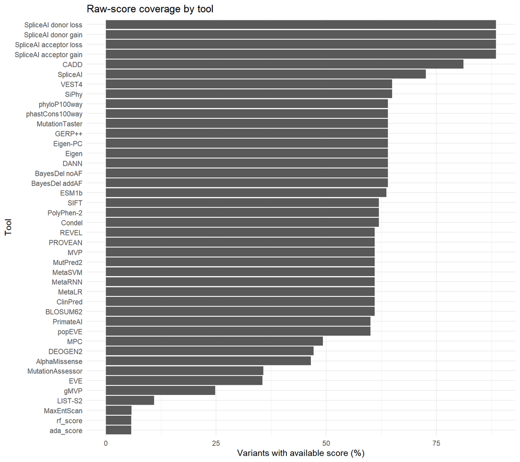

```r
raw_score_coverage_by_tool %>%
  arrange(percent_with_score) %>%
  ggplot(aes(x = percent_with_score, y = reorder(tool, percent_with_score))) +
  geom_col() +
  labs(
    title = "Raw-score coverage by tool",
    x = "Variants with available score (%)",
    y = "Tool"
  ) +
  theme_minimal()
```

# Step 4: Check key tools

```r
raw_score_coverage_by_tool %>%
  filter(
    tool %in% c(
      "CADD",
      "DANN",
      "Eigen-PC",
      "AlphaMissense",
      "EVE",
      "ESM1b",
      "REVEL",
      "SIFT",
      "PolyPhen-2"
    )
  ) %>%
  arrange(tool) %>%
  print(n = Inf, width = Inf)
```

```
## # A tibble: 9 × 7
##   tool          tool_classification               score_column
##   <chr>         <chr>                             <chr>
## 1 AlphaMissense Missense predictor                am_pathogenicity_new
## 2 CADD          General deleteriousness predictor CADD_PHRED_new
## 3 DANN          General deleteriousness predictor DANN_score_new
## 4 ESM1b         Protein language model predictor  ESM1b_score_new
## 5 EVE           Missense/evolutionary model       EVE_SCORE_new
## 6 Eigen-PC      Meta-predictor                    Eigen_PC_phred_coding_new
## 7 PolyPhen-2    Missense predictor                PolyPhen_score
## 8 REVEL         Meta-predictor                    REVEL_score_new
## 9 SIFT          Missense predictor                SIFT_score
##   total_variants variants_with_score variants_without_score percent_with_score
##            <int>               <int>                  <int>              <dbl>
## 1           1627                 757                    870               46.5
## 2           1627                1319                    308               81.1
## 3           1627                1042                    585               64
## 4           1627                1034                    593               63.6
## 5           1627                 577                   1050               35.5
## 6           1627                1042                    585               64
## 7           1627                1007                    620               61.9
## 8           1627                 992                    635               61
## 9           1627                1007                    620               61.9
```

```r
key_tool_raw_score_coverage <- raw_score_coverage_by_tool %>%
  filter(
    .data[["tool"]] %in% c(
      "CADD",
      "DANN",
      "Eigen-PC",
      "AlphaMissense",
      "EVE",
      "ESM1b",
      "REVEL",
      "SIFT",
      "PolyPhen-2",
      "PROVEAN",
      "MutPred2"
    )
  ) %>%
  arrange(.data[["tool"]])

key_tool_raw_score_coverage %>%
  print(n = Inf, width = Inf)
```

```
## # A tibble: 11 × 7
##    tool          tool_classification               score_column
##    <chr>         <chr>                             <chr>
##  1 AlphaMissense Missense predictor                am_pathogenicity_new
##  2 CADD          General deleteriousness predictor CADD_PHRED_new
##  3 DANN          General deleteriousness predictor DANN_score_new
##  4 ESM1b         Protein language model predictor  ESM1b_score_new
##  5 EVE           Missense/evolutionary model       EVE_SCORE_new
##  6 Eigen-PC      Meta-predictor                    Eigen_PC_phred_coding_new
##  7 MutPred2      Missense predictor                MutPred2_score_new
##  8 PROVEAN       Missense predictor                PROVEAN_score_new
##  9 PolyPhen-2    Missense predictor                PolyPhen_score
## 10 REVEL         Meta-predictor                    REVEL_score_new
## 11 SIFT          Missense predictor                SIFT_score
##    total_variants variants_with_score variants_without_score percent_with_score
##             <int>               <int>                  <int>              <dbl>
##  1           1627                 757                    870               46.5
##  2           1627                1319                    308               81.1
##  3           1627                1042                    585               64
##  4           1627                1034                    593               63.6
##  5           1627                 577                   1050               35.5
##  6           1627                1042                    585               64
##  7           1627                 992                    635               61
##  8           1627                 992                    635               61
##  9           1627                1007                    620               61.9
## 10           1627                 992                    635               61
## 11           1627                1007                    620               61.9
```

[output not shown]

[output cut: 30 more lines]

[output not shown]

##quality control of missense definition

```r
missense_definition_qc_after_fix <- ANALYSIS_DATASET_WITH_VARIANT_GROUPS %>%
  summarise(
    total_variants = n(),
    missing_effect_function = sum(variant_group_missing_effect_function, na.rm = TRUE),
    missense_total = sum(variant_group_missense, na.rm = TRUE),
    pure_missense = sum(
      variant_group_missense & !variant_group_splice,
      na.rm = TRUE
    ),
    missense_and_splice = sum(
      variant_group_missense & variant_group_splice,
      na.rm = TRUE
    ),
    regulatory_noncoding_total = sum(variant_group_regulatory_noncoding, na.rm = TRUE)
  )

missense_definition_qc_after_fix
```

```
## # A tibble: 1 × 6
##   total_variants missing_effect_function missense_total pure_missense
##            <int>                   <int>          <int>         <int>
## 1           1627                       0            998           960
## # ℹ 2 more variables: missense_and_splice <int>,
## #   regulatory_noncoding_total <int>
```

```r
readr::write_csv(
  missense_definition_qc_after_fix,
  file.path(output_directory, "corrected_missense_definition_qc.csv")
)
```

## qc table for the 5 discordant variants

```r
coding_discordant_missense_variants <- ANALYSIS_DATASET_WITH_VARIANT_GROUPS %>%
  filter(
    stringr::str_detect(effect_function_lower, "missense"),
    !stringr::str_detect(consequence_lower, "missense_variant"),
    !stringr::str_detect(
      consequence_lower,
      "intron|utr|upstream|downstream|non_coding|regulatory|promoter"
    )
  ) %>%
  select(
    any_of(c(
      "HGVS",
      "HGVS_transcript",
      "GRCh38 Vep_input",
      "Vep_input",
      "Effect_function",
      "Consequence",
      "Gene",
      "Gene_final",
      "Gene_new",
      "HGVS_protein",
      "HGVSp_new",
      "Feature_new",
      "MANE_SELECT_new"
    ))
  )

coding_discordant_missense_variants %>%
  print(n = Inf, width = Inf)
```

```
## # A tibble: 5 × 13
##   HGVS          HGVS_transcript       `GRCh38 Vep_input`
##   <chr>         <chr>                 <chr>
## 1 HBA2:c.326C>A NM_000517.4:c.326C>A  NC_000016.10:g.173498C>A
## 2 HBB:c.420T>C  NM_000518.4:c.420T>C  NC_000011.10:g.5225622A>G
## 3 HBB:c.81G>Y   NM_000518.4:c.81G>Y   NC_000011.10:g.5226941C>Y
## 4 HBB:c.48G>Y   NM_000518.4:c.48G>Y   NC_000011.10:g.5226974C>Y
## 5 HBB:c.417dupT NM_000518.4:c.417dupT NC_000011.10:g.5225625dup
##   Vep_input             Effect_function Consequence             Gene  Gene_final
##   <chr>                 <chr>           <chr>                   <chr> <chr>
## 1 NM_000517.4:c.327C>A  Missense codons synonymous_variant      HBA2  HBA2
## 2 NM_000518.4:c.420T>C  Missense codons synonymous_variant      HBB   HBB
## 3 NM_000518.4:c.81G>Y   Missense codons coding_sequence_variant HBB   HBB
## 4 NM_000518.4:c.48G>Y   Missense codons coding_sequence_variant HBB   HBB
## 5 NM_000518.4:c.417dupT Missense codons frameshift_variant      HBB   HBB
##   Gene_new        HGVS_protein          HGVSp_new Feature_new
##   <chr>           <chr>                 <chr>     <chr>
## 1 ENSG00000188536 NP_000508.1:p.(T109N) -         ENST00000251595.11
## 2 ENSG00000244734 NP_000509.1:p.(N140K) -         ENST00000335295.4
## 3 ENSG00000244734 NP_000509.1:p.(E27D)  -         ENST00000335295.4
## 4 ENSG00000244734 NP_000509.1:p.(W16C)  -         ENST00000335295.4
## 5 ENSG00000244734 NP_000509.1:p.(N140*) -         ENST00000335295.4
##   MANE_SELECT_new
##   <chr>
## 1 NM_000517.6
## 2 NM_000518.5
## 3 NM_000518.5
## 4 NM_000518.5
## 5 NM_000518.5
```

```r
readr::write_csv(
  coding_discordant_missense_variants,
  file.path(output_directory, "coding_discordant_missense_variants_qc.csv"))
```

```r
ANALYSIS_DATASET_WITH_VARIANT_GROUPS %>%
  count(Effect_function, sort = TRUE) %>%
  print(n = Inf)
```

```
## # A tibble: 31 × 2
##    Effect_function                                            n
##    <chr>                                                  <int>
##  1 Missense codons                                         1003
##  2 Frameshift                                               195
##  3 Inframe indels                                            68
##  4 Promoter                                                  61
##  5 Stop gained                                               51
##  6 Splice region variant; Missense codons                    34
##  7 5'UTR                                                     22
##  8 Splice region variant                                     22
##  9 Synonymous substitution                                   21
## 10 Initiation codon                                          19
## 11 Splice donor                                              19
## 12 Splice acceptor                                           17
```

[output cut: 19 more lines]

## identification of the suspicious missing 62 variants

```r
current_pure_missense_variants <- ANALYSIS_DATASET_WITH_VARIANT_GROUPS %>%
  filter(
    variant_group_missense == TRUE,
    variant_group_splice == FALSE
  ) %>%
  select(
    any_of(c(
      "HGVS",
      "HGVS_transcript",
      "GRCh38 Vep_input",
      "Vep_input",
      "Effect_function",
      "Consequence",
      "Gene",
      "Feature",
      "MANE_SELECT",
      "MANE")))

current_pure_missense_variants %>%
  summarise(
    current_pure_missense_n = n()
  )
```

```
## # A tibble: 1 × 1
##   current_pure_missense_n
##                     <int>
## 1                     960
```

```r
current_pure_missense_variants %>%
  count(Effect_function, Consequence, sort = TRUE) %>%
  print(n = Inf, width = Inf)
```

```
## # A tibble: 4 × 3
##   Effect_function Consequence                 n
##   <chr>           <chr>                   <int>
## 1 Missense codons missense_variant          955
## 2 Missense codons coding_sequence_variant     2
## 3 Missense codons synonymous_variant          2
## 4 Missense codons frameshift_variant          1
```

## inspecting the suspicious pure missense variants

```r
suspicious_pure_missense_variants <- current_pure_missense_variants %>%
  filter(
    stringr::str_detect(
      stringr::str_to_lower(Consequence),
      "intron|splice|utr|upstream|downstream|non_coding|regulatory|promoter"))

suspicious_pure_missense_variants %>%
  summarise(
    suspicious_pure_missense_n = n()
  )
```

```
## # A tibble: 1 × 1
##   suspicious_pure_missense_n
##                        <int>
## 1                          0
```

```r
suspicious_pure_missense_variants %>%
  print(n = Inf, width = Inf)
```

```
## # A tibble: 0 × 7
## # ℹ 7 variables: HGVS <chr>, HGVS_transcript <chr>, GRCh38 Vep_input <chr>, Vep_input <chr>, Effect_function <chr>, Consequence <chr>, Gene <chr>
```

```r
readr::write_csv(
  suspicious_pure_missense_variants,
  file.path(output_directory, "suspicious_pure_missense_variants_reclassified_by_vep.csv")
)
```

## creating a long variant group dataset

```r
variant_group_long_dataset <- dplyr::bind_rows(

  ANALYSIS_DATASET_WITH_VARIANT_GROUPS %>%
    mutate(variant_group = "All variants"),

  ANALYSIS_DATASET_WITH_VARIANT_GROUPS %>%
    filter(variant_group_missense) %>%
    mutate(variant_group = "Missense"),

  ANALYSIS_DATASET_WITH_VARIANT_GROUPS %>%
    filter(variant_group_splice) %>%
    mutate(variant_group = "Splice / cryptic splice"),

  ANALYSIS_DATASET_WITH_VARIANT_GROUPS %>%
    filter(variant_group_nonsense_stop) %>%
    mutate(variant_group = "Nonsense / stop"),

  ANALYSIS_DATASET_WITH_VARIANT_GROUPS %>%
    filter(variant_group_frameshift) %>%
    mutate(variant_group = "Frameshift"),

  ANALYSIS_DATASET_WITH_VARIANT_GROUPS %>%
    filter(variant_group_inframe_indel) %>%
    mutate(variant_group = "Inframe indel"),

  ANALYSIS_DATASET_WITH_VARIANT_GROUPS %>%
    filter(variant_group_synonymous) %>%
    mutate(variant_group = "Synonymous"),

  ANALYSIS_DATASET_WITH_VARIANT_GROUPS %>%
    filter(variant_group_regulatory_noncoding) %>%
    mutate(variant_group = "Regulatory / non-coding"),

  ANALYSIS_DATASET_WITH_VARIANT_GROUPS %>%
    filter(variant_group_initiation_codon) %>%
    mutate(variant_group = "Initiation codon"),

  ANALYSIS_DATASET_WITH_VARIANT_GROUPS %>%
    filter(variant_group_other) %>%
    mutate(variant_group = "Other")
)

variant_group_long_dataset %>%
  count(variant_group, name = "n_variants") %>%
  arrange(desc(n_variants)) %>%
  print(n = Inf, width = Inf)
```

```
## # A tibble: 9 × 2
##   variant_group           n_variants
##   <chr>                        <int>
## 1 All variants                  1627
## 2 Missense                       998
## 3 Regulatory / non-coding        220
## 4 Frameshift                     215
## 5 Splice / cryptic splice        127
## 6 Inframe indel                   70
## 7 Nonsense / stop                 68
## 8 Synonymous                      31
## 9 Initiation codon                19
```

## calculate coverage by tool and variant group

```r
raw_score_coverage_by_tool_and_variant_group <- purrr::map_dfr(
  seq_len(nrow(tool_reference_table)),
  function(i) {

    current_tool <- tool_reference_table$tool[i]
    current_classification <- tool_reference_table$tool_classification[i]
    current_score_column <- tool_reference_table$score_column[i]

    variant_group_long_dataset %>%
      group_by(variant_group) %>%
      summarise(
        tool = current_tool,
        tool_classification = current_classification,
        score_column = current_score_column,
        total_variants_in_group = n(),
        variants_with_score = sum(
          is_usable_tool_value(.data[[current_score_column]]),
          na.rm = TRUE
        ),
        variants_without_score = total_variants_in_group - variants_with_score,
        percent_with_score = round(
          variants_with_score / total_variants_in_group * 100,
          1
        ),
        .groups = "drop"
      )
  }
) %>%
  arrange(tool, variant_group)

raw_score_coverage_by_tool_and_variant_group %>%
  print(n = Inf, width = Inf)
```

```
## # A tibble: 378 × 8
##     variant_group           tool
##     <chr>                   <chr>
##   1 All variants            AlphaMissense
##   2 Frameshift              AlphaMissense
##   3 Inframe indel           AlphaMissense
##   4 Initiation codon        AlphaMissense
##   5 Missense                AlphaMissense
##   6 Nonsense / stop         AlphaMissense
##   7 Regulatory / non-coding AlphaMissense
##   8 Splice / cryptic splice AlphaMissense
##   9 Synonymous              AlphaMissense
##  10 All variants            BLOSUM62
##  11 Frameshift              BLOSUM62
##  12 Inframe indel           BLOSUM62
```

[output cut: 1506 more lines]

# Save the table

```r
readr::write_csv(
  raw_score_coverage_by_tool_and_variant_group,
  file.path(output_directory, "raw_score_coverage_by_tool_and_variant_group.csv")
)
```

## create a summary by tool classification to helps answer earlier point that coverage should include all tool classifications.

```r
coverage_by_tool_classification <- raw_score_coverage_by_tool_and_variant_group %>%
  group_by(tool_classification, variant_group) %>%
  summarise(
    number_of_tools = n(),
    mean_percent_with_score = round(mean(percent_with_score, na.rm = TRUE), 1),
    median_percent_with_score = round(median(percent_with_score, na.rm = TRUE), 1),
    min_percent_with_score = round(min(percent_with_score, na.rm = TRUE), 1),
    max_percent_with_score = round(max(percent_with_score, na.rm = TRUE), 1),
    .groups = "drop"
  ) %>%
  arrange(tool_classification, variant_group)

coverage_by_tool_classification %>%
  print(n = Inf, width = Inf)
```

```
## # A tibble: 90 × 7
##    tool_classification                        variant_group
##    <chr>                                      <chr>
##  1 Amino-acid substitution/conservation score All variants
##  2 Amino-acid substitution/conservation score Frameshift
##  3 Amino-acid substitution/conservation score Inframe indel
##  4 Amino-acid substitution/conservation score Initiation codon
##  5 Amino-acid substitution/conservation score Missense
##  6 Amino-acid substitution/conservation score Nonsense / stop
##  7 Amino-acid substitution/conservation score Regulatory / non-coding
##  8 Amino-acid substitution/conservation score Splice / cryptic splice
##  9 Amino-acid substitution/conservation score Synonymous
## 10 Conservation score                         All variants
## 11 Conservation score                         Frameshift
## 12 Conservation score                         Inframe indel
```

[output cut: 262 more lines]

```r
readr::write_csv(
  coverage_by_tool_classification,
  file.path(output_directory, "coverage_by_tool_classification.csv"))
```

##cleaned version of tool coverage table

```r
key_coverage_summary <- raw_score_coverage_by_tool_and_variant_group %>%
  filter(
    variant_group %in% c(
      "All variants",
      "Missense",
      "Splice / cryptic splice",
      "Nonsense / stop",
      "Regulatory / UTR / promoter",
      "Frameshift",
      "Indel / insertion / deletion"
    )
  ) %>%
  arrange(tool, variant_group)

key_coverage_summary %>%
  print(n = Inf, width = Inf)
```

```
## # A tibble: 210 × 8
##     variant_group           tool
##     <chr>                   <chr>
##   1 All variants            AlphaMissense
##   2 Frameshift              AlphaMissense
##   3 Missense                AlphaMissense
##   4 Nonsense / stop         AlphaMissense
##   5 Splice / cryptic splice AlphaMissense
##   6 All variants            BLOSUM62
##   7 Frameshift              BLOSUM62
##   8 Missense                BLOSUM62
##   9 Nonsense / stop         BLOSUM62
##  10 Splice / cryptic splice BLOSUM62
##  11 All variants            BayesDel addAF
##  12 Frameshift              BayesDel addAF
```

[output cut: 834 more lines]

```r
readr::write_csv(
  key_coverage_summary,
  file.path(output_directory, "key_coverage_summary.csv"))
```

##creating a focused AlphaMissense and EVE check to detemine why coverage is low

```r
alphamissense_eve_coverage_check <- raw_score_coverage_by_tool_and_variant_group %>%
  filter(
    tool %in% c("AlphaMissense", "EVE"),
    variant_group %in% c("All variants", "Missense", "Splice / cryptic splice")
  ) %>%
  arrange(tool, variant_group)

alphamissense_eve_coverage_check
```

```
## # A tibble: 6 × 8
##   variant_group    tool  tool_classification score_column total_variants_in_gr…¹
##   <chr>            <chr> <chr>               <chr>                         <int>
## 1 All variants     Alph… Missense predictor  am_pathogen…                   1627
## 2 Missense         Alph… Missense predictor  am_pathogen…                    998
## 3 Splice / crypti… Alph… Missense predictor  am_pathogen…                    127
## 4 All variants     EVE   Missense/evolution… EVE_SCORE_n…                   1627
## 5 Missense         EVE   Missense/evolution… EVE_SCORE_n…                    998
## 6 Splice / crypti… EVE   Missense/evolution… EVE_SCORE_n…                    127
## # ℹ abbreviated name: ¹total_variants_in_group
## # ℹ 3 more variables: variants_with_score <int>, variants_without_score <int>,
## #   percent_with_score <dbl>
```

```r
readr::write_csv(
  alphamissense_eve_coverage_check,
  file.path(output_directory, "alphamissense_eve_coverage_check.csv"))
```

##filtered version of table with relevant groups most important for interpretation

```r
main_coverage_summary_table <- raw_score_coverage_by_tool_and_variant_group %>%
  filter(
    variant_group %in% c(
      "All variants",
      "Missense",
      "Splice / cryptic splice",
      "Nonsense / stop",
      "Frameshift",
      "Inframe indel",
      "Regulatory / non-coding"
    )
  ) %>%
  arrange(tool_classification, tool, variant_group)

main_coverage_summary_table %>%
  print(n = Inf, width = Inf)
```

```
## # A tibble: 294 × 8
##     variant_group           tool
##     <chr>                   <chr>
##   1 All variants            BLOSUM62
##   2 Frameshift              BLOSUM62
##   3 Inframe indel           BLOSUM62
##   4 Missense                BLOSUM62
##   5 Nonsense / stop         BLOSUM62
##   6 Regulatory / non-coding BLOSUM62
##   7 Splice / cryptic splice BLOSUM62
##   8 All variants            GERP++
##   9 Frameshift              GERP++
##  10 Inframe indel           GERP++
##  11 Missense                GERP++
##  12 Nonsense / stop         GERP++
```

[output cut: 1170 more lines]

```r
readr::write_csv(
  main_coverage_summary_table,
  file.path(output_directory, "main_coverage_summary_table.csv"))
```

##confirming if variant grouping is correct

```r
effect_function_qc <- ANALYSIS_DATASET %>%
  count(Effect_function, sort = TRUE)

effect_function_qc %>%
  print(n = Inf)
```

```
## # A tibble: 31 × 2
##    Effect_function                                            n
##    <chr>                                                  <int>
##  1 Missense codons                                         1003
##  2 Frameshift                                               195
##  3 Inframe indels                                            68
##  4 Promoter                                                  61
##  5 Stop gained                                               51
##  6 Splice region variant; Missense codons                    34
##  7 5'UTR                                                     22
##  8 Splice region variant                                     22
##  9 Synonymous substitution                                   21
## 10 Initiation codon                                          19
## 11 Splice donor                                              19
## 12 Splice acceptor                                           17
```

[output cut: 19 more lines]

```r
readr::write_csv(
  effect_function_qc,
  file.path(output_directory, "effect_function_qc.csv"))
```

## binary performance analysis using default thresholds calculating various metrics

1. checking binary prediction columns

```r
binary_prediction_column_qc <- tool_reference_table %>%
  filter(include_in_binary_analysis == TRUE) %>%
  mutate(
    prediction_column_available = ifelse(
      is.na(prediction_column),
      FALSE,
      prediction_column %in% names(ANALYSIS_DATASET)
    ),
    score_column_available = score_column %in% names(ANALYSIS_DATASET),
    needs_threshold_conversion = is.na(prediction_column)
  )

binary_prediction_column_qc %>%
  select(
    tool,
    tool_classification,
    score_column,
    prediction_column,
    score_column_available,
    prediction_column_available,
    needs_threshold_conversion,
    default_threshold,
    threshold_source
  ) %>%
  print(n = Inf, width = Inf)
```

```
## # A tibble: 23 × 9
##    tool             tool_classification
##    <chr>            <chr>
##  1 SIFT             Missense predictor
##  2 PolyPhen-2       Missense predictor
##  3 PROVEAN          Missense predictor
##  4 MutationTaster   General functional predictor
##  5 MutationAssessor Missense predictor
##  6 MutPred2         Missense predictor
##  7 DEOGEN2          Missense predictor
##  8 PrimateAI        Missense predictor
##  9 REVEL            Meta-predictor
## 10 ClinPred         Meta-predictor
## 11 MetaSVM          Meta-predictor
## 12 MetaLR           Meta-predictor
```

[output cut: 86 more lines]

## inspecting prediction label values to determine the correct labels used by each tool

```r
prediction_label_qc <- tool_reference_table %>%
  filter(
    include_in_binary_analysis == TRUE,
    !is.na(prediction_column)
  ) %>%
  select(tool, prediction_column) %>%
  purrr::pmap_dfr(
    function(tool, prediction_column) {

      ANALYSIS_DATASET %>%
        count(
          prediction_label = .data[[prediction_column]],
          name = "n"
        ) %>%
        mutate(
          tool = tool,
          prediction_column = prediction_column,
          .before = 1
        )
    }
  ) %>%
  arrange(tool, desc(n))

prediction_label_qc %>%
  print(n = Inf, width = Inf)
```

```
## # A tibble: 188 × 4
##     tool             prediction_column         prediction_label
##     <chr>            <chr>                     <chr>
##   1 AlphaMissense    am_class_new              -
##   2 AlphaMissense    am_class_new              likely_pathogenic
##   3 AlphaMissense    am_class_new              likely_benign
##   4 AlphaMissense    am_class_new              ambiguous
##   5 BayesDel addAF   BayesDel_addAF_pred_new   D
##   6 BayesDel addAF   BayesDel_addAF_pred_new   -
##   7 BayesDel addAF   BayesDel_addAF_pred_new   T
##   8 BayesDel noAF    BayesDel_noAF_pred_new    D
##   9 BayesDel noAF    BayesDel_noAF_pred_new    -
##  10 BayesDel noAF    BayesDel_noAF_pred_new    T
##  11 ClinPred         ClinPred_pred_new         D
##  12 ClinPred         ClinPred_pred_new         -
```

[output cut: 366 more lines]

```r
readr::write_csv(
  prediction_label_qc,
  file.path(output_directory, "prediction_label_qc.csv"))
```

##standardise tool labels before performance analysis

```r
# ============================================================
# Create clean binary predictions for tool-performance analysis
# ============================================================

clean_numeric_score <- function(x) {
  x <- as.character(x)
  x[x %in% c("", "-", ".", "NA", "na", "N/A")] <- NA
  as.numeric(x)
}

classify_prediction_label <- function(x) {

  x_clean <- stringr::str_to_lower(as.character(x))

  dplyr::case_when(
    is.na(x_clean) ~ NA_character_,
    x_clean %in% c("", "-", ".", "na", "n/a") ~ NA_character_,

    # Pathogenic-like labels
    x_clean %in% c(
      "d",
      "pathogenic",
      "likely_pathogenic",
      "probably_damaging",
      "possibly_damaging",
      "h",
      "a",
      "s",
      "pp",
      "ps",
      "pm"
    ) ~ "Pathogenic",

    stringr::str_detect(x_clean, "^deleterious") ~ "Pathogenic",
    stringr::str_detect(x_clean, "^probably_damaging") ~ "Pathogenic",
    stringr::str_detect(x_clean, "^possibly_damaging") ~ "Pathogenic",

    # MutationTaster mixed labels
    stringr::str_detect(x_clean, "(^|,)d(,|$)") ~ "Pathogenic",
    stringr::str_detect(x_clean, "(^|,)a(,|$)") ~ "Pathogenic",

    # Benign-like labels
    x_clean %in% c(
      "t",
      "b",
      "benign",
      "likely_benign",
      "n",
      "l",
      "bm",
      "bp"
    ) ~ "Benign",

    stringr::str_detect(x_clean, "^tolerated") ~ "Benign",
    stringr::str_detect(x_clean, "^benign") ~ "Benign",
    stringr::str_detect(x_clean, "(^|,)n(,|$)") ~ "Benign",

    # Uncertain labels
    x_clean %in% c(
      "ambiguous",
      "uncertain",
      "uc",
      "m"
    ) ~ NA_character_,

    TRUE ~ NA_character_
  )
}

classify_mutationassessor_label <- function(x) {

  x_clean <- stringr::str_to_lower(as.character(x))

  dplyr::case_when(
    is.na(x_clean) ~ NA_character_,
    x_clean %in% c("", "-", ".", "na", "n/a") ~ NA_character_,

    # MutationAssessor-specific labels
    # H = high impact, M = medium impact
    x_clean %in% c("h", "m") ~ "Pathogenic",

    # L = low impact, N = neutral
    x_clean %in% c("l", "n") ~ "Benign",

    TRUE ~ NA_character_
  )
}

classify_popeve_label <- function(x) {

  x_clean <- stringr::str_to_lower(as.character(x))

  dplyr::case_when(
    is.na(x_clean) ~ NA_character_,
    x_clean %in% c("", "-", ".", "na", "n/a") ~ NA_character_,

    # popEVE-specific labels
    # S = severe/pathogenic-like
    # B = benign-like
    # M = moderate/uncertain, excluded from binary analysis
    x_clean == "s" ~ "Pathogenic",
    x_clean == "b" ~ "Benign",
    x_clean == "m" ~ NA_character_,

    TRUE ~ NA_character_
  )
}

# Extract thresholds
CADD_threshold <- tool_reference_table %>%
  filter(tool == "CADD") %>%
  pull(default_threshold)

DANN_threshold <- tool_reference_table %>%
  filter(tool == "DANN") %>%
  pull(default_threshold)

Eigen_PC_threshold <- tool_reference_table %>%
  filter(tool == "Eigen-PC") %>%
  pull(default_threshold)
```

```r
# Check that the original clinical-classification column exists
if (!"Observed_pathogenicity" %in% names(FINAL_MERGED_DATASET)) {
  stop(
    "The column 'Observed_pathogenicity' was not found in FINAL_MERGED_DATASET.\n",
    "Available columns include:\n",
    paste(names(FINAL_MERGED_DATASET), collapse = ", ")
  )
}

FINAL_MERGED_DATASET <- FINAL_MERGED_DATASET %>%
  dplyr::mutate(
    observed_classification = stringr::str_squish(
      as.character(Observed_pathogenicity)
    ),

    observed_binary = dplyr::case_when(
      observed_classification %in% c(
        "P",
        "LP",
        "P/LP",
        "Pathogenic",
        "Likely pathogenic",
        "Pathogenic/Likely pathogenic",
        "Pathogenic or likely pathogenic"
      ) ~ "Pathogenic",

      observed_classification %in% c(
        "B",
        "LB",
        "B/LB",
        "Benign",
        "Likely benign",
        "Benign/Likely benign",
        "Benign or likely benign"
      ) ~ "Benign",

      observed_classification %in% c(
        "VUS",
        "Uncertain significance",
        "Variant of uncertain significance"
      ) ~ "VUS",

      TRUE ~ NA_character_
    )
  )

# Summarise the recoded classifications
observed_binary_summary <- FINAL_MERGED_DATASET %>%
  dplyr::count(
    observed_classification,
    observed_binary,
    name = "n"
  ) %>%
  dplyr::arrange(
    observed_binary,
    dplyr::desc(n)
  )

observed_binary_summary
```

```
## # A tibble: 3 × 3
##   observed_classification observed_binary     n
##   <chr>                   <chr>           <int>
## 1 B/LB                    Benign            194
## 2 P/LP                    Pathogenic        832
## 3 VUS                     VUS               601
```

Then create the binary-analysis dataset with:

## create binary analysis dataset

```r
BINARY_ANALYSIS_DATASET <- FINAL_MERGED_DATASET %>%
  dplyr::filter(
    observed_binary %in% c("Pathogenic", "Benign")
  ) %>%
  dplyr::mutate(
    observed_binary = factor(
      observed_binary,
      levels = c("Benign", "Pathogenic")
    )
  )

cat(
  "Binary analysis dataset created successfully.\n",
  "Rows:", nrow(BINARY_ANALYSIS_DATASET), "\n",
  "Columns:", ncol(BINARY_ANALYSIS_DATASET), "\n"
)
```

```
## Binary analysis dataset created successfully.
##  Rows: 1026
##  Columns: 649
```

```r
BINARY_ANALYSIS_DATASET %>%
  dplyr::count(
    observed_binary,
    name = "n"
  )
```

```
## # A tibble: 2 × 2
##   observed_binary     n
##   <fct>           <int>
## 1 Benign            194
## 2 Pathogenic        832
```

```r
binary_tool_reference <- binary_prediction_column_qc %>%
  dplyr::filter(
    include_in_binary_analysis == TRUE
  ) %>%
  dplyr::mutate(
    prediction_column_exists =
      !is.na(prediction_column) &
      prediction_column %in% names(BINARY_ANALYSIS_DATASET),

    score_column_exists =
      !is.na(score_column) &
      score_column %in% names(BINARY_ANALYSIS_DATASET),

    threshold_available =
      !is.na(default_threshold),

    analysis_method = dplyr::case_when(
      prediction_column_exists ~ "Prediction label",
      score_column_exists & threshold_available ~ "Score threshold",
      TRUE ~ "Not currently analysable"
    )
  )

binary_tool_reference %>%
  dplyr::select(
    tool,
    score_column,
    prediction_column,
    prediction_column_exists,
    score_column_exists,
    default_threshold,
    analysis_method
  ) %>%
  print(n = Inf)
```

```
## # A tibble: 23 × 7
##    tool             score_column        prediction_column prediction_column_ex…¹
##    <chr>            <chr>               <chr>             <lgl>
##  1 SIFT             SIFT_score          SIFT_new          TRUE
##  2 PolyPhen-2       PolyPhen_score      PolyPhen_new      TRUE
##  3 PROVEAN          PROVEAN_score_new   PROVEAN_pred_new  TRUE
##  4 MutationTaster   MutationTaster_sco… MutationTaster_p… TRUE
##  5 MutationAssessor MutationAssessor_s… MutationAssessor… TRUE
##  6 MutPred2         MutPred2_score_new  MutPred2_pred_new TRUE
##  7 DEOGEN2          DEOGEN2_score_new   DEOGEN2_pred_new  TRUE
##  8 PrimateAI        PrimateAI_score_new PrimateAI_pred_n… TRUE
##  9 REVEL            REVEL_score_new     <NA>              FALSE
## 10 ClinPred         ClinPred_score_new  ClinPred_pred_new TRUE
## 11 MetaSVM          MetaSVM_score_new   MetaSVM_pred_new  TRUE
## 12 MetaLR           MetaLR_score_new    MetaLR_pred_new   TRUE
## 13 MetaRNN          MetaRNN_score_new   MetaRNN_pred_new  TRUE
## 14 BayesDel addAF   BayesDel_addAF_sco… BayesDel_addAF_p… TRUE
## 15 BayesDel noAF    BayesDel_noAF_scor… BayesDel_noAF_pr… TRUE
## 16 LIST-S2          LIST_S2_score_new   LIST_S2_pred_new  TRUE
## 17 CADD             CADD_PHRED_new      <NA>              FALSE
## 18 DANN             DANN_score_new      <NA>              FALSE
## 19 Eigen-PC         Eigen_PC_phred_cod… <NA>              FALSE
## 20 AlphaMissense    am_pathogenicity_n… am_class_new      TRUE
## 21 EVE              EVE_SCORE_new       EVE_CLASS_new     TRUE
## 22 ESM1b            ESM1b_score_new     ESM1b_pred_new    TRUE
## 23 popEVE           popEVE_SCORE_1_new  popEVE_pred_new   TRUE
## # ℹ abbreviated name: ¹prediction_column_exists
## # ℹ 3 more variables: score_column_exists <lgl>, default_threshold <dbl>,
## #   analysis_method <chr>
```

# Create binary performance dataset

```r
# =============================================================================
# 1. Validate the source dataset
# =============================================================================

if (!exists("FINAL_MERGED_DATASET")) {
  stop(
    "FINAL_MERGED_DATASET does not exist. ",
    "Run the final merge and classification chunks first."
  )
}

if (!"observed_binary" %in% names(FINAL_MERGED_DATASET)) {
  stop(
    "The column 'observed_binary' is missing from FINAL_MERGED_DATASET."
  )
}


# =============================================================================
# 2. Validate the helper classification functions
# =============================================================================

required_functions <- c(
  "classify_prediction_label",
  "classify_mutationassessor_label",
  "classify_popeve_label"
)

missing_functions <- required_functions[
  !vapply(
    required_functions,
    exists,
    logical(1),
    mode = "function"
  )
]

if (length(missing_functions) > 0) {
  stop(
    "The following classification functions have not been created: ",
    paste(missing_functions, collapse = ", "),
    ". Run their definition chunks first."
  )
}


# =============================================================================
# 3. Validate the required predictor columns
# =============================================================================

required_predictor_columns <- c(
  "SIFT_new",
  "PolyPhen_new",
  "PolyPhen_score",
  "PROVEAN_pred_new",
  "MutationTaster_pred_new",
  "MutationAssessor_pred_new",
  "MutPred2_pred_new",
  "DEOGEN2_pred_new",
  "PrimateAI_pred_new",
  "ClinPred_pred_new",
  "MetaSVM_pred_new",
  "MetaLR_pred_new",
  "MetaRNN_pred_new",
  "BayesDel_addAF_pred_new",
  "BayesDel_noAF_pred_new",
  "LIST_S2_pred_new",
  "am_class_new",
  "EVE_CLASS_new",
  "ESM1b_pred_new",
  "popEVE_pred_new",
  "CADD_PHRED_new",
  "DANN_score_new",
  "Eigen_PC_phred_coding_new"
)

missing_predictor_columns <- setdiff(
  required_predictor_columns,
  names(FINAL_MERGED_DATASET)
)

if (length(missing_predictor_columns) > 0) {
  stop(
    "The following required predictor columns are missing:\n",
    paste(missing_predictor_columns, collapse = "\n")
  )
}


# =============================================================================
# 4. PolyPhen-2 classification helper
# =============================================================================
# The categorical label is used first.
# The score threshold is used only when the label is missing.

classify_polyphen_label_or_score <- function(
  polyphen_label,
  polyphen_score
) {

  label_clean <- classify_prediction_label(
    polyphen_label
  )

  score_numeric <- suppressWarnings(
    as.numeric(
      as.character(polyphen_score)
    )
  )

  dplyr::case_when(
    !is.na(label_clean) ~ label_clean,

    is.na(label_clean) &
      !is.na(score_numeric) &
      score_numeric >= 0.453 ~ "Pathogenic",

    is.na(label_clean) &
      !is.na(score_numeric) &
      score_numeric < 0.453 ~ "Benign",

    TRUE ~ NA_character_
  )
}


# =============================================================================
# 5. Create the binary performance dataset
# =============================================================================

BINARY_PERFORMANCE_DATASET <- FINAL_MERGED_DATASET %>%

  dplyr::filter(
    observed_binary %in% c(
      "Pathogenic",
      "Benign"
    )
  ) %>%

  dplyr::mutate(

    # -------------------------------------------------------------------------
    # Prediction-label tools
    # -------------------------------------------------------------------------

    SIFT_predicted_clean =
      classify_prediction_label(
        SIFT_new
      ),

    PolyPhen_predicted_clean =
      classify_polyphen_label_or_score(
        polyphen_label = PolyPhen_new,
        polyphen_score = PolyPhen_score
      ),

    PROVEAN_predicted_clean =
      classify_prediction_label(
        PROVEAN_pred_new
      ),

    MutationTaster_predicted_clean =
      classify_prediction_label(
        MutationTaster_pred_new
      ),

    MutationAssessor_predicted_clean =
      classify_mutationassessor_label(
        MutationAssessor_pred_new
      ),

    MutPred2_predicted_clean =
      classify_prediction_label(
        MutPred2_pred_new
      ),

    DEOGEN2_predicted_clean =
      classify_prediction_label(
        DEOGEN2_pred_new
      ),

    PrimateAI_predicted_clean =
      classify_prediction_label(
        PrimateAI_pred_new
      ),

    ClinPred_predicted_clean =
      classify_prediction_label(
        ClinPred_pred_new
      ),

    MetaSVM_predicted_clean =
      classify_prediction_label(
        MetaSVM_pred_new
      ),

    MetaLR_predicted_clean =
      classify_prediction_label(
        MetaLR_pred_new
      ),

    MetaRNN_predicted_clean =
      classify_prediction_label(
        MetaRNN_pred_new
      ),

    BayesDel_addAF_predicted_clean =
      classify_prediction_label(
        BayesDel_addAF_pred_new
      ),

    BayesDel_noAF_predicted_clean =
      classify_prediction_label(
        BayesDel_noAF_pred_new
      ),

    LIST_S2_predicted_clean =
      classify_prediction_label(
        LIST_S2_pred_new
      ),

    AlphaMissense_predicted_clean =
      classify_prediction_label(
        am_class_new
      ),

    EVE_predicted_clean =
      classify_prediction_label(
        EVE_CLASS_new
      ),

    ESM1b_predicted_clean =
      classify_prediction_label(
        ESM1b_pred_new
      ),

    popEVE_predicted_clean =
      classify_popeve_label(
        popEVE_pred_new
      ),

    # -------------------------------------------------------------------------
    # Convert continuous scores to numeric
    # -------------------------------------------------------------------------

    CADD_score_numeric = suppressWarnings(
      as.numeric(
        as.character(CADD_PHRED_new)
      )
    ),

    DANN_score_numeric = suppressWarnings(
      as.numeric(
        as.character(DANN_score_new)
      )
    ),

    Eigen_PC_score_numeric = suppressWarnings(
      as.numeric(
        as.character(Eigen_PC_phred_coding_new)
      )
    ),

    # -------------------------------------------------------------------------
    # Continuous-score tools using the thresholds from your original analysis
    # -------------------------------------------------------------------------

    CADD_predicted_clean = dplyr::case_when(
      !is.na(CADD_score_numeric) &
        CADD_score_numeric >= 10.44 ~ "Pathogenic",

      !is.na(CADD_score_numeric) &
        CADD_score_numeric < 10.44 ~ "Benign",

      TRUE ~ NA_character_
    ),

    DANN_predicted_clean = dplyr::case_when(
      !is.na(DANN_score_numeric) &
        DANN_score_numeric >= 0.971 ~ "Pathogenic",

      !is.na(DANN_score_numeric) &
        DANN_score_numeric < 0.971 ~ "Benign",

      TRUE ~ NA_character_
    ),

    Eigen_PC_predicted_clean = dplyr::case_when(
      !is.na(Eigen_PC_score_numeric) &
        Eigen_PC_score_numeric >= 1.3 ~ "Pathogenic",

      !is.na(Eigen_PC_score_numeric) &
        Eigen_PC_score_numeric < 1.3 ~ "Benign",

      TRUE ~ NA_character_
    )
  )


# =============================================================================
# 6. Validate the cleaned prediction columns
# =============================================================================

required_clean_prediction_columns <- c(
  "SIFT_predicted_clean",
  "PolyPhen_predicted_clean",
  "PROVEAN_predicted_clean",
  "MutationTaster_predicted_clean",
  "MutationAssessor_predicted_clean",
  "MutPred2_predicted_clean",
  "DEOGEN2_predicted_clean",
  "PrimateAI_predicted_clean",
  "ClinPred_predicted_clean",
  "MetaSVM_predicted_clean",
  "MetaLR_predicted_clean",
  "MetaRNN_predicted_clean",
  "BayesDel_addAF_predicted_clean",
  "BayesDel_noAF_predicted_clean",
  "LIST_S2_predicted_clean",
  "AlphaMissense_predicted_clean",
  "EVE_predicted_clean",
  "ESM1b_predicted_clean",
  "popEVE_predicted_clean",
  "CADD_predicted_clean",
  "DANN_predicted_clean",
  "Eigen_PC_predicted_clean"
)

missing_clean_prediction_columns <- setdiff(
  required_clean_prediction_columns,
  names(BINARY_PERFORMANCE_DATASET)
)

if (length(missing_clean_prediction_columns) > 0) {
  stop(
    "The following cleaned prediction columns were not created:\n",
    paste(
      missing_clean_prediction_columns,
      collapse = "\n"
    )
  )
}


# =============================================================================
# 7. Confirm that the cleaned predictions contain valid values
# =============================================================================

valid_binary_predictions <- c(
  "Pathogenic",
  "Benign"
)

invalid_prediction_values <- BINARY_PERFORMANCE_DATASET %>%
  dplyr::select(
    dplyr::all_of(
      required_clean_prediction_columns
    )
  ) %>%
  tidyr::pivot_longer(
    cols = dplyr::everything(),
    names_to = "prediction_column",
    values_to = "prediction"
  ) %>%
  dplyr::filter(
    !is.na(prediction),
    !prediction %in% valid_binary_predictions
  ) %>%
  dplyr::distinct(
    prediction_column,
    prediction
  )

if (nrow(invalid_prediction_values) > 0) {
  warning(
    "Some cleaned prediction columns contain values other than ",
    "'Pathogenic', 'Benign', or NA. ",
    "Inspect invalid_prediction_values."
  )
}


# =============================================================================
# 8. Create a dataset-level summary
# =============================================================================

binary_performance_dataset_summary <-
  BINARY_PERFORMANCE_DATASET %>%
  dplyr::summarise(
    total_binary_variants = dplyr::n(),

    pathogenic = sum(
      observed_binary == "Pathogenic",
      na.rm = TRUE
    ),

    benign = sum(
      observed_binary == "Benign",
      na.rm = TRUE
    ),

    polyphen_clean_available = sum(
      !is.na(PolyPhen_predicted_clean)
    ),

    popeve_clean_available = sum(
      !is.na(popEVE_predicted_clean)
    ),

    cadd_clean_available = sum(
      !is.na(CADD_predicted_clean)
    ),

    dann_clean_available = sum(
      !is.na(DANN_predicted_clean)
    ),

    eigen_pc_clean_available = sum(
      !is.na(Eigen_PC_predicted_clean)
    )
  )


# =============================================================================
# 9. Create availability counts for all tools
# =============================================================================

binary_prediction_availability <-
  BINARY_PERFORMANCE_DATASET %>%
  dplyr::summarise(
    dplyr::across(
      dplyr::all_of(
        required_clean_prediction_columns
      ),
      ~ sum(!is.na(.x))
    )
  ) %>%
  tidyr::pivot_longer(
    cols = dplyr::everything(),
    names_to = "prediction_column",
    values_to = "n_with_prediction"
  ) %>%
  dplyr::mutate(
    total_binary_variants =
      nrow(BINARY_PERFORMANCE_DATASET),

    coverage_percent = round(
      n_with_prediction /
        total_binary_variants *
        100,
      2
    )
  ) %>%
  dplyr::arrange(
    dplyr::desc(coverage_percent)
  )


# =============================================================================
# 10. Display confirmation and summaries
# =============================================================================

cat(
  "BINARY_PERFORMANCE_DATASET created successfully.\n",
  "Rows:",
  nrow(BINARY_PERFORMANCE_DATASET),
  "\n",
  "Columns:",
  ncol(BINARY_PERFORMANCE_DATASET),
  "\n",
  "Cleaned prediction columns:",
  length(required_clean_prediction_columns),
  "\n"
)
```

```
## BINARY_PERFORMANCE_DATASET created successfully.
##  Rows: 1026
##  Columns: 674
##  Cleaned prediction columns: 22
```

```r
binary_performance_dataset_summary
```

```
## # A tibble: 1 × 8
##   total_binary_variants pathogenic benign polyphen_clean_available
##                   <int>      <int>  <int>                    <int>
## 1                  1026        832    194                      481
## # ℹ 4 more variables: popeve_clean_available <int>, cadd_clean_available <int>,
## #   dann_clean_available <int>, eigen_pc_clean_available <int>
```

```r
binary_prediction_availability
```

```
## # A tibble: 22 × 4
##    prediction_column    n_with_prediction total_binary_variants coverage_percent
##    <chr>                            <int>                 <int>            <dbl>
##  1 CADD_predicted_clean               742                  1026             72.3
##  2 BayesDel_addAF_pred…               522                  1026             50.9
##  3 BayesDel_noAF_predi…               522                  1026             50.9
##  4 DANN_predicted_clean               522                  1026             50.9
##  5 Eigen_PC_predicted_…               522                  1026             50.9
##  6 ESM1b_predicted_cle…               514                  1026             50.1
##  7 PolyPhen_predicted_…               481                  1026             46.9
##  8 SIFT_predicted_clean               472                  1026             46
##  9 PROVEAN_predicted_c…               472                  1026             46
## 10 ClinPred_predicted_…               472                  1026             46
## # ℹ 12 more rows
```

````
``` r
classify_polyphen_label_or_score <- function(polyphen_label, polyphen_score) {

  label_clean <- classify_prediction_label(polyphen_label)
  score_numeric <- as.numeric(polyphen_score)

  dplyr::case_when(
    !is.na(label_clean) ~ label_clean,
    is.na(label_clean) & !is.na(score_numeric) & score_numeric >= 0.453 ~ "Pathogenic",
    is.na(label_clean) & !is.na(score_numeric) & score_numeric < 0.453 ~ "Benign",
    TRUE ~ NA_character_
  )
}
````

```r
clean_prediction_qc <- BINARY_PERFORMANCE_DATASET %>%
  summarise(
    SIFT = sum(!is.na(SIFT_predicted_clean)),
    PolyPhen = sum(!is.na(PolyPhen_predicted_clean)),
    PROVEAN = sum(!is.na(PROVEAN_predicted_clean)),
    MutationTaster = sum(!is.na(MutationTaster_predicted_clean)),
    MutationAssessor = sum(!is.na(MutationAssessor_predicted_clean)),
    MutPred2 = sum(!is.na(MutPred2_predicted_clean)),
    DEOGEN2 = sum(!is.na(DEOGEN2_predicted_clean)),
    PrimateAI = sum(!is.na(PrimateAI_predicted_clean)),
    ClinPred = sum(!is.na(ClinPred_predicted_clean)),
    MetaSVM = sum(!is.na(MetaSVM_predicted_clean)),
    MetaLR = sum(!is.na(MetaLR_predicted_clean)),
    MetaRNN = sum(!is.na(MetaRNN_predicted_clean)),
    BayesDel_addAF = sum(!is.na(BayesDel_addAF_predicted_clean)),
    BayesDel_noAF = sum(!is.na(BayesDel_noAF_predicted_clean)),
    LIST_S2 = sum(!is.na(LIST_S2_predicted_clean)),
    AlphaMissense = sum(!is.na(AlphaMissense_predicted_clean)),
    EVE = sum(!is.na(EVE_predicted_clean)),
    ESM1b = sum(!is.na(ESM1b_predicted_clean)),
    popEVE = sum(!is.na(popEVE_predicted_clean)),
    CADD = sum(!is.na(CADD_predicted_clean)),
    DANN = sum(!is.na(DANN_predicted_clean)),
    Eigen_PC = sum(!is.na(Eigen_PC_predicted_clean))
  ) %>%
  tidyr::pivot_longer(
    cols = everything(),
    names_to = "tool",
    values_to = "n_binary_predictions"
  ) %>%
  arrange(desc(n_binary_predictions))

clean_prediction_qc %>%
  print(n = Inf)
```

```
## # A tibble: 22 × 2
##    tool             n_binary_predictions
##    <chr>                           <int>
##  1 CADD                              742
##  2 BayesDel_addAF                    522
##  3 BayesDel_noAF                     522
##  4 DANN                              522
##  5 Eigen_PC                          522
##  6 ESM1b                             514
##  7 PolyPhen                          481
##  8 SIFT                              472
##  9 PROVEAN                           472
## 10 ClinPred                          472
## 11 MetaSVM                           472
## 12 MetaLR                            472
## 13 MetaRNN                           472
## 14 PrimateAI                         457
## 15 MutationTaster                    447
## 16 DEOGEN2                           335
## 17 MutPred2                          291
## 18 AlphaMissense                     283
## 19 MutationAssessor                  224
## 20 LIST_S2                           103
## 21 EVE                                75
## 22 popEVE                             67
```

## quality check for polyphen and popEVE

```r
BINARY_PERFORMANCE_DATASET %>%
  count(PolyPhen_predicted_clean, sort = TRUE) %>%
  print(n = Inf, width = Inf)
```

```
## # A tibble: 3 × 2
##   PolyPhen_predicted_clean     n
##   <chr>                    <int>
## 1 <NA>                       545
## 2 Pathogenic                 307
## 3 Benign                     174
```

```r
BINARY_PERFORMANCE_DATASET %>%
  count(popEVE_pred_new, sort = TRUE) %>%
  print(n = Inf, width = Inf)
```

```
## # A tibble: 4 × 2
##   popEVE_pred_new     n
##   <chr>           <int>
## 1 -                 923
## 2 B                  39
## 3 M                  36
## 4 S                  28
```

```r
BINARY_PERFORMANCE_DATASET %>%
  count(popEVE_predicted_clean, sort = TRUE) %>%
  print(n = Inf, width = Inf)
```

```
## # A tibble: 3 × 2
##   popEVE_predicted_clean     n
##   <chr>                  <int>
## 1 <NA>                     959
## 2 Benign                    39
## 3 Pathogenic                28
```

```r
BINARY_PERFORMANCE_DATASET %>%
  summarise(
    total_binary_variants = n(),
    polyphen_score_available = sum(!is.na(PolyPhen_score), na.rm = TRUE),
    polyphen_label_available = sum(!is.na(PolyPhen_new), na.rm = TRUE),
    polyphen_clean_available = sum(!is.na(PolyPhen_predicted_clean), na.rm = TRUE)
  )
```

```
## # A tibble: 1 × 4
##   total_binary_variants polyphen_score_available polyphen_label_available
##                   <int>                    <int>                    <int>
## 1                  1026                      481                     1026
## # ℹ 1 more variable: polyphen_clean_available <int>
```

```r
BINARY_PERFORMANCE_DATASET %>%
  count(PolyPhen_predicted_clean, sort = TRUE) %>%
  print(n = Inf, width = Inf)
```

```
## # A tibble: 3 × 2
##   PolyPhen_predicted_clean     n
##   <chr>                    <int>
## 1 <NA>                       545
## 2 Pathogenic                 307
## 3 Benign                     174
```

```r
safe_divide <- function(numerator, denominator) {
  ifelse(
    denominator == 0,
    NA_real_,
    numerator / denominator
  )
}

calculate_binary_tool_performance <- function(
  data,
  observed_col,
  predicted_col,
  tool_name
) {

  performance_data <- data %>%
    dplyr::filter(
      !is.na(.data[[observed_col]]),
      !is.na(.data[[predicted_col]])
    )

  TP <- sum(
    performance_data[[observed_col]] == "Pathogenic" &
      performance_data[[predicted_col]] == "Pathogenic",
    na.rm = TRUE
  )

  TN <- sum(
    performance_data[[observed_col]] == "Benign" &
      performance_data[[predicted_col]] == "Benign",
    na.rm = TRUE
  )

  FP <- sum(
    performance_data[[observed_col]] == "Benign" &
      performance_data[[predicted_col]] == "Pathogenic",
    na.rm = TRUE
  )

  FN <- sum(
    performance_data[[observed_col]] == "Pathogenic" &
      performance_data[[predicted_col]] == "Benign",
    na.rm = TRUE
  )

  # Convert counts to numeric before multiplication
  TP <- as.numeric(TP)
  TN <- as.numeric(TN)
  FP <- as.numeric(FP)
  FN <- as.numeric(FN)

  n_evaluated <- TP + TN + FP + FN

  sensitivity <- safe_divide(TP, TP + FN)
  specificity <- safe_divide(TN, TN + FP)

  mcc_denominator <- sqrt(
    (TP + FP) *
      (TP + FN) *
      (TN + FP) *
      (TN + FN)
  )

  mcc <- safe_divide(
    (TP * TN) - (FP * FN),
    mcc_denominator
  )

  LR_positive <- safe_divide(
    sensitivity,
    1 - specificity
  )

  LR_negative <- safe_divide(
    1 - sensitivity,
    specificity
  )

  tibble::tibble(
    tool = tool_name,
    prediction_column = predicted_col,
    total_eligible_binary_variants = nrow(data),
    n_evaluated = n_evaluated,
    variants_not_evaluated =
      nrow(data) - n_evaluated,
    true_positive = TP,
    true_negative = TN,
    false_positive = FP,
    false_negative = FN,
    accuracy = round(
      safe_divide(
        TP + TN,
        n_evaluated
      ),
      3
    ),
    sensitivity = round(
      sensitivity,
      3
    ),
    specificity = round(
      specificity,
      3
    ),
    ppv = round(
      safe_divide(
        TP,
        TP + FP
      ),
      3
    ),
    npv = round(
      safe_divide(
        TN,
        TN + FN
      ),
      3
    ),
    balanced_accuracy = round(
      ifelse(
        is.na(sensitivity) |
          is.na(specificity),
        NA_real_,
        mean(
          c(
            sensitivity,
            specificity
          ),
          na.rm = TRUE
        )
      ),
      3
    ),
    mcc = round(
      mcc,
      3
    ),
    LR_positive = round(
      LR_positive,
      3
    ),
    LR_negative = round(
      LR_negative,
      3
    )
  )
}

cat(
  "Safe binary performance function created successfully.\n"
)
```

```
## Safe binary performance function created successfully.
```

```r
required_clean_prediction_columns <- c(
  "SIFT_predicted_clean",
  "PolyPhen_predicted_clean",
  "PROVEAN_predicted_clean",
  "MutationTaster_predicted_clean",
  "MutationAssessor_predicted_clean",
  "MutPred2_predicted_clean",
  "DEOGEN2_predicted_clean",
  "PrimateAI_predicted_clean",
  "ClinPred_predicted_clean",
  "MetaSVM_predicted_clean",
  "MetaLR_predicted_clean",
  "MetaRNN_predicted_clean",
  "BayesDel_addAF_predicted_clean",
  "BayesDel_noAF_predicted_clean",
  "LIST_S2_predicted_clean",
  "AlphaMissense_predicted_clean",
  "EVE_predicted_clean",
  "ESM1b_predicted_clean",
  "popEVE_predicted_clean",
  "CADD_predicted_clean",
  "DANN_predicted_clean",
  "Eigen_PC_predicted_clean"
)

if (!exists("BINARY_PERFORMANCE_DATASET")) {
  stop(
    "BINARY_PERFORMANCE_DATASET does not exist. ",
    "Run the chunk that creates the cleaned binary prediction columns first."
  )
}

if (!exists("calculate_binary_tool_performance")) {
  stop(
    "The function 'calculate_binary_tool_performance' does not exist. ",
    "Run the function-definition chunk first."
  )
}

if (!"observed_binary" %in% names(BINARY_PERFORMANCE_DATASET)) {
  stop(
    "The column 'observed_binary' is missing from ",
    "BINARY_PERFORMANCE_DATASET."
  )
}

missing_prediction_columns <- setdiff(
  required_clean_prediction_columns,
  names(BINARY_PERFORMANCE_DATASET)
)

if (length(missing_prediction_columns) > 0) {
  stop(
    "The following cleaned prediction columns are missing:\n",
    paste(missing_prediction_columns, collapse = "\n")
  )
}

cat(
  "Binary performance inputs validated successfully.\n",
  "Rows:", nrow(BINARY_PERFORMANCE_DATASET), "\n",
  "Prediction columns:", length(required_clean_prediction_columns), "\n")
```

```
## Binary performance inputs validated successfully.
##  Rows: 1026
##  Prediction columns: 22
```

##determinig binary tool performance

This will identify exactly what is missing instead of failing later with an unclear object-not-found error.

## 2. Use this cleaned version of your original summary chunk

```r
# =============================================================================
# Validate required objects
# =============================================================================

if (!exists("BINARY_PERFORMANCE_DATASET")) {
  stop(
    "BINARY_PERFORMANCE_DATASET does not exist. ",
    "Run the binary performance dataset chunk first."
  )
}

if (!exists(
  "calculate_binary_tool_performance",
  mode = "function"
)) {
  stop(
    "The function 'calculate_binary_tool_performance' does not exist. ",
    "Run the function-definition chunk first."
  )
}

required_prediction_columns <- c(
  "SIFT_predicted_clean",
  "PolyPhen_predicted_clean",
  "PROVEAN_predicted_clean",
  "MutationTaster_predicted_clean",
  "MutationAssessor_predicted_clean",
  "MutPred2_predicted_clean",
  "DEOGEN2_predicted_clean",
  "PrimateAI_predicted_clean",
  "ClinPred_predicted_clean",
  "MetaSVM_predicted_clean",
  "MetaLR_predicted_clean",
  "MetaRNN_predicted_clean",
  "BayesDel_addAF_predicted_clean",
  "BayesDel_noAF_predicted_clean",
  "LIST_S2_predicted_clean",
  "AlphaMissense_predicted_clean",
  "EVE_predicted_clean",
  "ESM1b_predicted_clean",
  "popEVE_predicted_clean",
  "CADD_predicted_clean",
  "DANN_predicted_clean",
  "Eigen_PC_predicted_clean"
)

missing_prediction_columns <- setdiff(
  required_prediction_columns,
  names(BINARY_PERFORMANCE_DATASET)
)

if (length(missing_prediction_columns) > 0) {
  stop(
    "The following cleaned prediction columns are missing:\n",
    paste(
      missing_prediction_columns,
      collapse = "\n"
    )
  )
}

if (!"observed_binary" %in% names(BINARY_PERFORMANCE_DATASET)) {
  stop(
    "The column 'observed_binary' is missing from ",
    "BINARY_PERFORMANCE_DATASET."
  )
}


# =============================================================================
# Calculate performance for all tools
# =============================================================================

binary_tool_performance_summary <- dplyr::bind_rows(

  calculate_binary_tool_performance(
    data = BINARY_PERFORMANCE_DATASET,
    observed_col = "observed_binary",
    predicted_col = "SIFT_predicted_clean",
    tool_name = "SIFT"
  ),

  calculate_binary_tool_performance(
    data = BINARY_PERFORMANCE_DATASET,
    observed_col = "observed_binary",
    predicted_col = "PolyPhen_predicted_clean",
    tool_name = "PolyPhen-2"
  ),

  calculate_binary_tool_performance(
    data = BINARY_PERFORMANCE_DATASET,
    observed_col = "observed_binary",
    predicted_col = "PROVEAN_predicted_clean",
    tool_name = "PROVEAN"
  ),

  calculate_binary_tool_performance(
    data = BINARY_PERFORMANCE_DATASET,
    observed_col = "observed_binary",
    predicted_col = "MutationTaster_predicted_clean",
    tool_name = "MutationTaster"
  ),

  calculate_binary_tool_performance(
    data = BINARY_PERFORMANCE_DATASET,
    observed_col = "observed_binary",
    predicted_col = "MutationAssessor_predicted_clean",
    tool_name = "MutationAssessor"
  ),

  calculate_binary_tool_performance(
    data = BINARY_PERFORMANCE_DATASET,
    observed_col = "observed_binary",
    predicted_col = "MutPred2_predicted_clean",
    tool_name = "MutPred2"
  ),

  calculate_binary_tool_performance(
    data = BINARY_PERFORMANCE_DATASET,
    observed_col = "observed_binary",
    predicted_col = "DEOGEN2_predicted_clean",
    tool_name = "DEOGEN2"
  ),

  calculate_binary_tool_performance(
    data = BINARY_PERFORMANCE_DATASET,
    observed_col = "observed_binary",
    predicted_col = "PrimateAI_predicted_clean",
    tool_name = "PrimateAI"
  ),

  calculate_binary_tool_performance(
    data = BINARY_PERFORMANCE_DATASET,
    observed_col = "observed_binary",
    predicted_col = "ClinPred_predicted_clean",
    tool_name = "ClinPred"
  ),

  calculate_binary_tool_performance(
    data = BINARY_PERFORMANCE_DATASET,
    observed_col = "observed_binary",
    predicted_col = "MetaSVM_predicted_clean",
    tool_name = "MetaSVM"
  ),

  calculate_binary_tool_performance(
    data = BINARY_PERFORMANCE_DATASET,
    observed_col = "observed_binary",
    predicted_col = "MetaLR_predicted_clean",
    tool_name = "MetaLR"
  ),

  calculate_binary_tool_performance(
    data = BINARY_PERFORMANCE_DATASET,
    observed_col = "observed_binary",
    predicted_col = "MetaRNN_predicted_clean",
    tool_name = "MetaRNN"
  ),

  calculate_binary_tool_performance(
    data = BINARY_PERFORMANCE_DATASET,
    observed_col = "observed_binary",
    predicted_col = "BayesDel_addAF_predicted_clean",
    tool_name = "BayesDel addAF"
  ),

  calculate_binary_tool_performance(
    data = BINARY_PERFORMANCE_DATASET,
    observed_col = "observed_binary",
    predicted_col = "BayesDel_noAF_predicted_clean",
    tool_name = "BayesDel noAF"
  ),

  calculate_binary_tool_performance(
    data = BINARY_PERFORMANCE_DATASET,
    observed_col = "observed_binary",
    predicted_col = "LIST_S2_predicted_clean",
    tool_name = "LIST-S2"
  ),

  calculate_binary_tool_performance(
    data = BINARY_PERFORMANCE_DATASET,
    observed_col = "observed_binary",
    predicted_col = "AlphaMissense_predicted_clean",
    tool_name = "AlphaMissense"
  ),

  calculate_binary_tool_performance(
    data = BINARY_PERFORMANCE_DATASET,
    observed_col = "observed_binary",
    predicted_col = "EVE_predicted_clean",
    tool_name = "EVE"
  ),

  calculate_binary_tool_performance(
    data = BINARY_PERFORMANCE_DATASET,
    observed_col = "observed_binary",
    predicted_col = "ESM1b_predicted_clean",
    tool_name = "ESM1b"
  ),

  calculate_binary_tool_performance(
    data = BINARY_PERFORMANCE_DATASET,
    observed_col = "observed_binary",
    predicted_col = "popEVE_predicted_clean",
    tool_name = "popEVE"
  ),

  calculate_binary_tool_performance(
    data = BINARY_PERFORMANCE_DATASET,
    observed_col = "observed_binary",
    predicted_col = "CADD_predicted_clean",
    tool_name = "CADD"
  ),

  calculate_binary_tool_performance(
    data = BINARY_PERFORMANCE_DATASET,
    observed_col = "observed_binary",
    predicted_col = "DANN_predicted_clean",
    tool_name = "DANN"
  ),

  calculate_binary_tool_performance(
    data = BINARY_PERFORMANCE_DATASET,
    observed_col = "observed_binary",
    predicted_col = "Eigen_PC_predicted_clean",
    tool_name = "Eigen-PC"
  )
) %>%

  # Keep valid MCC values above missing MCC values
  dplyr::arrange(
    is.na(mcc),
    dplyr::desc(mcc)
  )


# =============================================================================
# Validate the final summary
# =============================================================================

if (nrow(binary_tool_performance_summary) == 0) {
  stop(
    "The binary tool performance summary was created but contains no rows."
  )
}

if (nrow(binary_tool_performance_summary) != 22) {
  warning(
    "Expected 22 tools, but the summary contains ",
    nrow(binary_tool_performance_summary),
    " rows."
  )
}

required_metric_columns <- c(
  "tool",
  "prediction_column",
  "total_eligible_binary_variants",
  "n_evaluated",
  "variants_not_evaluated",
  "true_positive",
  "true_negative",
  "false_positive",
  "false_negative",
  "accuracy",
  "sensitivity",
  "specificity",
  "ppv",
  "npv",
  "balanced_accuracy",
  "mcc",
  "LR_positive",
  "LR_negative"
)

missing_metric_columns <- setdiff(
  required_metric_columns,
  names(binary_tool_performance_summary)
)

if (length(missing_metric_columns) > 0) {
  stop(
    "The performance summary is missing these metric columns:\n",
    paste(
      missing_metric_columns,
      collapse = "\n"
    )
  )
}


# =============================================================================
# Display results
# =============================================================================

cat(
  "Binary tool performance summary created successfully.\n",
  "Tools evaluated:",
  nrow(binary_tool_performance_summary),
  "\n"
)
```

```
## Binary tool performance summary created successfully.
##  Tools evaluated: 22
```

```r
print(
  binary_tool_performance_summary,
  n = Inf,
  width = Inf
)
```

```
## # A tibble: 22 × 18
##    tool             prediction_column
##    <chr>            <chr>
##  1 MutPred2         MutPred2_predicted_clean
##  2 CADD             CADD_predicted_clean
##  3 AlphaMissense    AlphaMissense_predicted_clean
##  4 Eigen-PC         Eigen_PC_predicted_clean
##  5 popEVE           popEVE_predicted_clean
##  6 SIFT             SIFT_predicted_clean
##  7 MutationAssessor MutationAssessor_predicted_clean
##  8 DANN             DANN_predicted_clean
##  9 PolyPhen-2       PolyPhen_predicted_clean
## 10 ESM1b            ESM1b_predicted_clean
## 11 LIST-S2          LIST_S2_predicted_clean
## 12 MetaSVM          MetaSVM_predicted_clean
```

[output cut: 106 more lines]

```r
readr::write_csv(
  binary_tool_performance_summary,
  file.path(
    tables_directory,
    "binary_tool_performance_summary.csv"
  ))
```

## fixing od CADD and polyphen2 missing figures

```r
binary_performance_summary_with_coverage <- binary_tool_performance_summary %>%
  mutate(
    percent_binary_variants_evaluated = round(
      n_evaluated / total_eligible_binary_variants * 100,
      1
    )
  ) %>%
  arrange(desc(mcc))

binary_performance_summary_with_coverage %>%
  select(
    tool,
    total_eligible_binary_variants,
    n_evaluated,
    percent_binary_variants_evaluated,
    accuracy,
    sensitivity,
    specificity,
    balanced_accuracy,
    mcc,
    LR_positive,
    LR_negative
  ) %>%
  print(n = Inf, width = Inf)
```

```
## # A tibble: 22 × 11
##    tool             total_eligible_binary_variants n_evaluated
##    <chr>                                     <int>       <dbl>
##  1 MutPred2                                   1026         291
##  2 CADD                                       1026         742
##  3 AlphaMissense                              1026         283
##  4 Eigen-PC                                   1026         522
##  5 popEVE                                     1026          67
##  6 SIFT                                       1026         472
##  7 MutationAssessor                           1026         224
##  8 DANN                                       1026         522
##  9 PolyPhen-2                                 1026         481
## 10 ESM1b                                      1026         514
## 11 LIST-S2                                    1026         103
## 12 MetaSVM                                    1026         472
```

[output cut: 58 more lines]

```r
readr::write_csv(
  binary_performance_summary_with_coverage,
  file.path(output_directory, "binary_performance_summary_with_coverage.csv"))
```

##top tools performance summary

```r
top_performing_binary_tools <- binary_performance_summary_with_coverage %>%
  filter(
    n_evaluated >= 100
  ) %>%
  arrange(desc(mcc)) %>%
  slice_head(n = 10)

top_performing_binary_tools %>%
  print(n = Inf, width = Inf)
```

```
## # A tibble: 10 × 19
##    tool             prediction_column
##    <chr>            <chr>
##  1 MutPred2         MutPred2_predicted_clean
##  2 CADD             CADD_predicted_clean
##  3 AlphaMissense    AlphaMissense_predicted_clean
##  4 Eigen-PC         Eigen_PC_predicted_clean
##  5 SIFT             SIFT_predicted_clean
##  6 MutationAssessor MutationAssessor_predicted_clean
##  7 DANN             DANN_predicted_clean
##  8 PolyPhen-2       PolyPhen_predicted_clean
##  9 ESM1b            ESM1b_predicted_clean
## 10 LIST-S2          LIST_S2_predicted_clean
##    total_eligible_binary_variants n_evaluated variants_not_evaluated
##                             <int>       <dbl>                  <dbl>
```

[output cut: 46 more lines]

```r
readr::write_csv(
  top_performing_binary_tools,
  file.path(output_directory, "top_performing_binary_tools.csv"))
```

```r
binary_prediction_tool_map <- tibble::tribble(
  ~tool, ~prediction_column,
  "SIFT", "SIFT_predicted_clean",
  "PolyPhen-2", "PolyPhen_predicted_clean",
  "PROVEAN", "PROVEAN_predicted_clean",
  "MutationTaster", "MutationTaster_predicted_clean",
  "MutationAssessor", "MutationAssessor_predicted_clean",
  "MutPred2", "MutPred2_predicted_clean",
  "DEOGEN2", "DEOGEN2_predicted_clean",
  "PrimateAI", "PrimateAI_predicted_clean",
  "ClinPred", "ClinPred_predicted_clean",
  "MetaSVM", "MetaSVM_predicted_clean",
  "MetaLR", "MetaLR_predicted_clean",
  "MetaRNN", "MetaRNN_predicted_clean",
  "BayesDel addAF", "BayesDel_addAF_predicted_clean",
  "BayesDel noAF", "BayesDel_noAF_predicted_clean",
  "LIST-S2", "LIST_S2_predicted_clean",
  "AlphaMissense", "AlphaMissense_predicted_clean",
  "EVE", "EVE_predicted_clean",
  "ESM1b", "ESM1b_predicted_clean",
  "popEVE", "popEVE_predicted_clean",
  "CADD", "CADD_predicted_clean",
  "DANN", "DANN_predicted_clean",
  "Eigen-PC", "Eigen_PC_predicted_clean"
)

binary_prediction_tool_map_available <- binary_prediction_tool_map %>%
  filter(
    prediction_column %in% names(BINARY_PERFORMANCE_DATASET)
  )

binary_prediction_tool_map_available %>%
  print(n = Inf, width = Inf)
```

```
## # A tibble: 22 × 2
##    tool             prediction_column
##    <chr>            <chr>
##  1 SIFT             SIFT_predicted_clean
##  2 PolyPhen-2       PolyPhen_predicted_clean
##  3 PROVEAN          PROVEAN_predicted_clean
##  4 MutationTaster   MutationTaster_predicted_clean
##  5 MutationAssessor MutationAssessor_predicted_clean
##  6 MutPred2         MutPred2_predicted_clean
##  7 DEOGEN2          DEOGEN2_predicted_clean
##  8 PrimateAI        PrimateAI_predicted_clean
##  9 ClinPred         ClinPred_predicted_clean
## 10 MetaSVM          MetaSVM_predicted_clean
## 11 MetaLR           MetaLR_predicted_clean
## 12 MetaRNN          MetaRNN_predicted_clean
## 13 BayesDel addAF   BayesDel_addAF_predicted_clean
## 14 BayesDel noAF    BayesDel_noAF_predicted_clean
## 15 LIST-S2          LIST_S2_predicted_clean
## 16 AlphaMissense    AlphaMissense_predicted_clean
## 17 EVE              EVE_predicted_clean
## 18 ESM1b            ESM1b_predicted_clean
## 19 popEVE           popEVE_predicted_clean
## 20 CADD             CADD_predicted_clean
## 21 DANN             DANN_predicted_clean
## 22 Eigen-PC         Eigen_PC_predicted_clean
```

```r
if (!exists("BINARY_PERFORMANCE_DATASET")) {
  stop(
    "BINARY_PERFORMANCE_DATASET does not exist. ",
    "Run the binary performance dataset chunk first."
  )
}

if (!"Effect_function" %in%
    names(BINARY_PERFORMANCE_DATASET)) {
  stop(
    "Effect_function is missing from ",
    "BINARY_PERFORMANCE_DATASET."
  )
}

MISSENSE_BINARY_PERFORMANCE_DATASET <-
  BINARY_PERFORMANCE_DATASET %>%
  dplyr::mutate(
    effect_function_lower =
      stringr::str_to_lower(Effect_function)
  ) %>%
  dplyr::filter(
    stringr::str_detect(
      effect_function_lower,
      "missense"
    )
  )

if (nrow(MISSENSE_BINARY_PERFORMANCE_DATASET) == 0) {
  stop(
    "No missense variants were found in ",
    "BINARY_PERFORMANCE_DATASET."
  )
}

MISSENSE_BINARY_PERFORMANCE_DATASET %>%
  dplyr::summarise(
    total_missense_binary_variants = dplyr::n(),
    pathogenic_reference = sum(
      observed_binary == "Pathogenic",
      na.rm = TRUE
    ),
    benign_reference = sum(
      observed_binary == "Benign",
      na.rm = TRUE
    ))
```

```
## # A tibble: 1 × 3
##   total_missense_binary_variants pathogenic_reference benign_reference
##                            <int>                <int>            <int>
## 1                            511                  355              156
```

##calculate missense only bianary performance

```r
if (!exists("MISSENSE_BINARY_PERFORMANCE_DATASET")) {
  stop(
    "MISSENSE_BINARY_PERFORMANCE_DATASET does not exist."
  )
}

available_missense_tool_map <-
  binary_prediction_tool_map %>%
  dplyr::filter(
    prediction_column %in%
      names(MISSENSE_BINARY_PERFORMANCE_DATASET)
  )

missense_binary_tool_performance_summary <-
  purrr::map2_dfr(
    available_missense_tool_map$tool,
    available_missense_tool_map$prediction_column,
    ~ calculate_binary_tool_performance(
      data = MISSENSE_BINARY_PERFORMANCE_DATASET,
      observed_col = "observed_binary",
      predicted_col = .y,
      tool_name = .x
    )
  ) %>%
  dplyr::arrange(
    is.na(mcc),
    dplyr::desc(mcc),
    dplyr::desc(n_evaluated)
  )

missense_binary_tool_performance_summary
```

```
## # A tibble: 22 × 18
##    tool             prediction_column         total_eligible_binar…¹ n_evaluated
##    <chr>            <chr>                                      <int>       <dbl>
##  1 MutPred2         MutPred2_predicted_clean                     511         277
##  2 AlphaMissense    AlphaMissense_predicted_…                    511         283
##  3 CADD             CADD_predicted_clean                         511         508
##  4 Eigen-PC         Eigen_PC_predicted_clean                     511         457
##  5 popEVE           popEVE_predicted_clean                       511          66
##  6 DANN             DANN_predicted_clean                         511         457
##  7 SIFT             SIFT_predicted_clean                         511         457
##  8 MutationAssessor MutationAssessor_predict…                    511         224
##  9 ESM1b            ESM1b_predicted_clean                        511         457
## 10 PolyPhen-2       PolyPhen_predicted_clean                     511         466
## # ℹ 12 more rows
## # ℹ abbreviated name: ¹total_eligible_binary_variants
## # ℹ 14 more variables: variants_not_evaluated <dbl>, true_positive <dbl>,
## #   true_negative <dbl>, false_positive <dbl>, false_negative <dbl>,
## #   accuracy <dbl>, sensitivity <dbl>, specificity <dbl>, ppv <dbl>, npv <dbl>,
## #   balanced_accuracy <dbl>, mcc <dbl>, LR_positive <dbl>, LR_negative <dbl>
```

## Chunk 3: Add coverage and interpretation notes

```r
missense_binary_performance_summary_with_coverage <- missense_binary_tool_performance_summary %>%
  mutate(
    percent_missense_binary_variants_evaluated = round(
      n_evaluated / total_eligible_binary_variants * 100,
      1
    )
  ) %>%
  arrange(desc(mcc))

missense_binary_performance_summary_with_coverage %>%
  select(
    tool,
    total_eligible_binary_variants,
    n_evaluated,
    percent_missense_binary_variants_evaluated,
    accuracy,
    sensitivity,
    specificity,
    balanced_accuracy,
    mcc,
    LR_positive,
    LR_negative
  ) %>%
  print(n = Inf, width = Inf)
```

```
## # A tibble: 22 × 11
##    tool             total_eligible_binary_variants n_evaluated
##    <chr>                                     <int>       <dbl>
##  1 MutPred2                                    511         277
##  2 AlphaMissense                               511         283
##  3 CADD                                        511         508
##  4 Eigen-PC                                    511         457
##  5 popEVE                                      511          66
##  6 DANN                                        511         457
##  7 SIFT                                        511         457
##  8 MutationAssessor                            511         224
##  9 ESM1b                                       511         457
## 10 PolyPhen-2                                  511         466
## 11 LIST-S2                                     511         101
## 12 MetaSVM                                     511         457
```

[output cut: 58 more lines]

```r
top_performing_missense_tools <- missense_binary_performance_summary_with_coverage %>%
  filter(
    n_evaluated >= 50,
    !is.na(mcc)
  ) %>%
  arrange(desc(mcc)) %>%
  slice_head(n = 10)

top_performing_missense_tools %>%
  select(
    tool,
    total_eligible_binary_variants,
    n_evaluated,
    percent_missense_binary_variants_evaluated,
    accuracy,
    sensitivity,
    specificity,
    balanced_accuracy,
    mcc,
    LR_positive,
    LR_negative
  ) %>%
  print(n = Inf, width = Inf)
```

```
## # A tibble: 10 × 11
##    tool             total_eligible_binary_variants n_evaluated
##    <chr>                                     <int>       <dbl>
##  1 MutPred2                                    511         277
##  2 AlphaMissense                               511         283
##  3 CADD                                        511         508
##  4 Eigen-PC                                    511         457
##  5 popEVE                                      511          66
##  6 DANN                                        511         457
##  7 SIFT                                        511         457
##  8 MutationAssessor                            511         224
##  9 ESM1b                                       511         457
## 10 PolyPhen-2                                  511         466
##    percent_missense_binary_variants_evaluated accuracy sensitivity specificity
##                                         <dbl>    <dbl>       <dbl>       <dbl>
```

[output cut: 22 more lines]

##common-subset compariosn: this allows s the comparison of selected tools only on the same variants to allow for a fair ranking as all tools are evaluated on identical missense variants

```r
selected_common_subset_tools <- c(
  "MutPred2_predicted_clean",
  "AlphaMissense_predicted_clean",
  "Eigen_PC_predicted_clean",
  "DANN_predicted_clean",
  "SIFT_predicted_clean",
  "ESM1b_predicted_clean",
  "PolyPhen_predicted_clean",
  "CADD_predicted_clean"
)

selected_common_subset_tool_names <- c(
  "MutPred2",
  "AlphaMissense",
  "Eigen-PC",
  "DANN",
  "SIFT",
  "ESM1b",
  "PolyPhen-2",
  "CADD"
)

COMMON_MISSENSE_BINARY_DATASET <- MISSENSE_BINARY_PERFORMANCE_DATASET %>%
  filter(
    dplyr::if_all(
      dplyr::all_of(selected_common_subset_tools),
      ~ !is.na(.x)
    )
  )

COMMON_MISSENSE_BINARY_DATASET %>%
  summarise(
    total_common_missense_binary_variants = n(),
    pathogenic = sum(observed_binary == "Pathogenic", na.rm = TRUE),
    benign = sum(observed_binary == "Benign", na.rm = TRUE)
  )
```

```
## # A tibble: 1 × 3
##   total_common_missense_binary_variants pathogenic benign
##                                   <int>      <int>  <int>
## 1                                   181        153     28
```

## calculation of common missense performance

```r
common_missense_subset_performance <- purrr::map2_dfr(
  selected_common_subset_tools,
  selected_common_subset_tool_names,
  ~ calculate_binary_tool_performance(
    data = COMMON_MISSENSE_BINARY_DATASET,
    observed_col = "observed_binary",
    predicted_col = .x,
    tool_name = .y
  )
) %>%
  arrange(desc(mcc))

common_missense_subset_performance %>%
  select(
    tool,
    total_eligible_binary_variants,
    n_evaluated,
    accuracy,
    sensitivity,
    specificity,
    balanced_accuracy,
    mcc,
    LR_positive,
    LR_negative
  ) %>%
  print(n = Inf, width = Inf)
```

```
## # A tibble: 8 × 10
##   tool          total_eligible_binary_variants n_evaluated accuracy sensitivity
##   <chr>                                  <int>       <dbl>    <dbl>       <dbl>
## 1 AlphaMissense                            181         181    0.917       0.961
## 2 MutPred2                                 181         181    0.906       0.948
## 3 Eigen-PC                                 181         181    0.89        0.948
## 4 DANN                                     181         181    0.884       0.948
## 5 ESM1b                                    181         181    0.867       0.922
## 6 PolyPhen-2                               181         181    0.851       0.889
## 7 SIFT                                     181         181    0.884       0.974
## 8 CADD                                     181         181    0.884       0.987
##   specificity balanced_accuracy   mcc LR_positive LR_negative
##         <dbl>             <dbl> <dbl>       <dbl>       <dbl>
## 1       0.679             0.82  0.67         2.99       0.058
## 2       0.679             0.814 0.636        2.95       0.077
## 3       0.571             0.759 0.554        2.21       0.092
## 4       0.536             0.742 0.525        2.04       0.098
## 5       0.571             0.746 0.493        2.15       0.137
## 6       0.643             0.766 0.487        2.49       0.173
## 7       0.393             0.683 0.481        1.60       0.067
## 8       0.321             0.654 0.467        1.45       0.041
```

```r
readr::write_csv(
  COMMON_MISSENSE_BINARY_DATASET,
  file.path(output_directory, "common_missense_binary_dataset_selected_tools.csv")
)

readr::write_csv(
  common_missense_subset_performance,
  file.path(output_directory, "common_missense_subset_performance_selected_tools.csv")
)
```

```r
readr::write_csv(
  MISSENSE_BINARY_PERFORMANCE_DATASET,
  file.path(output_directory, "corrected_missense_binary_performance_dataset_after_polyphen_fix.csv")
)

readr::write_csv(
  missense_binary_tool_performance_summary,
  file.path(output_directory, "corrected_missense_binary_tool_performance_summary_after_polyphen_fix.csv")
)

readr::write_csv(
  missense_binary_performance_summary_with_coverage,
  file.path(output_directory, "corrected_missense_binary_performance_summary_with_coverage_after_polyphen_fix.csv")
)

readr::write_csv(
  top_performing_missense_tools,
  file.path(output_directory, "corrected_top_performing_missense_tools_after_polyphen_fix.csv")
)
```

```r
readr::write_csv(
  MISSENSE_BINARY_PERFORMANCE_DATASET,
  file.path(output_directory, "corrected_missense_binary_performance_dataset.csv")
)

readr::write_csv(
  missense_binary_tool_performance_summary,
  file.path(output_directory, "corrected_missense_binary_tool_performance_summary.csv")
)

readr::write_csv(
  missense_binary_performance_summary_with_coverage,
  file.path(output_directory, "corrected_missense_binary_performance_summary_with_coverage.csv")
)

readr::write_csv(
  top_performing_missense_tools,
  file.path(output_directory, "corrected_top_performing_missense_tools.csv")
)
```

##clean summary table comparing the analysis of whole binary dataset,corrected missense only dataset and common missense subset

```r
whole_dataset_summary_for_comparison <- binary_performance_summary_with_coverage %>%
  select(
    tool,
    whole_n_evaluated = n_evaluated,
    whole_coverage_percent = percent_binary_variants_evaluated,
    whole_accuracy = accuracy,
    whole_sensitivity = sensitivity,
    whole_specificity = specificity,
    whole_balanced_accuracy = balanced_accuracy,
    whole_mcc = mcc
  )

missense_summary_for_comparison <- missense_binary_performance_summary_with_coverage %>%
  select(
    tool,
    missense_n_evaluated = n_evaluated,
    missense_coverage_percent = percent_missense_binary_variants_evaluated,
    missense_accuracy = accuracy,
    missense_sensitivity = sensitivity,
    missense_specificity = specificity,
    missense_balanced_accuracy = balanced_accuracy,
    missense_mcc = mcc
  )

common_subset_summary_for_comparison <- common_missense_subset_performance %>%
  select(
    tool,
    common_subset_n_evaluated = n_evaluated,
    common_subset_accuracy = accuracy,
    common_subset_sensitivity = sensitivity,
    common_subset_specificity = specificity,
    common_subset_balanced_accuracy = balanced_accuracy,
    common_subset_mcc = mcc
  )

main_analysis_comparison_summary <- whole_dataset_summary_for_comparison %>%
  full_join(
    missense_summary_for_comparison,
    by = "tool"
  ) %>%
  full_join(
    common_subset_summary_for_comparison,
    by = "tool"
  ) %>%
  arrange(desc(missense_mcc))

main_analysis_comparison_summary %>%
  print(n = Inf, width = Inf)
```

```
## # A tibble: 22 × 21
##    tool             whole_n_evaluated whole_coverage_percent whole_accuracy
##    <chr>                        <dbl>                  <dbl>          <dbl>
##  1 MutPred2                       291                   28.4          0.863
##  2 AlphaMissense                  283                   27.6          0.813
##  3 CADD                           742                   72.3          0.819
##  4 Eigen-PC                       522                   50.9          0.81
##  5 popEVE                          67                    6.5          0.657
##  6 DANN                           522                   50.9          0.778
##  7 SIFT                           472                   46            0.79
##  8 MutationAssessor               224                   21.8          0.871
##  9 ESM1b                          514                   50.1          0.759
## 10 PolyPhen-2                     481                   46.9          0.694
## 11 LIST-S2                        103                   10            0.65
## 12 MetaSVM                        472                   46            0.767
```

[output cut: 154 more lines]

```r
readr::write_csv(
  main_analysis_comparison_summary,
  file.path(output_directory, "main_analysis_comparison_summary.csv")
)
```

##compare whole dataset against missense only rankings

```r
whole_vs_missense_performance_comparison <- binary_performance_summary_with_coverage %>%
  select(
    tool,
    whole_dataset_evaluated = n_evaluated,
    whole_dataset_mcc = mcc,
    whole_dataset_balanced_accuracy = balanced_accuracy,
    whole_dataset_sensitivity = sensitivity,
    whole_dataset_specificity = specificity
  ) %>%
  left_join(
    missense_binary_performance_summary_with_coverage %>%
      select(
        tool,
        missense_evaluated = n_evaluated,
        missense_mcc = mcc,
        missense_balanced_accuracy = balanced_accuracy,
        missense_sensitivity = sensitivity,
        missense_specificity = specificity
      ),
    by = "tool"
  ) %>%
  mutate(
    mcc_change_missense_minus_whole = round(
      missense_mcc - whole_dataset_mcc,
      3
    ),
    balanced_accuracy_change_missense_minus_whole = round(
      missense_balanced_accuracy - whole_dataset_balanced_accuracy,
      3
    )
  ) %>%
  arrange(desc(missense_mcc))

whole_vs_missense_performance_comparison %>%
  print(n = Inf, width = Inf)
```

```
## # A tibble: 22 × 13
##    tool             whole_dataset_evaluated whole_dataset_mcc
##    <chr>                              <dbl>             <dbl>
##  1 MutPred2                             291             0.641
##  2 AlphaMissense                        283             0.46
##  3 CADD                                 742             0.484
##  4 Eigen-PC                             522             0.432
##  5 popEVE                                67             0.35
##  6 DANN                                 522             0.336
##  7 SIFT                                 472             0.347
##  8 MutationAssessor                     224             0.336
##  9 ESM1b                                514             0.278
## 10 PolyPhen-2                           481             0.299
## 11 LIST-S2                              103             0.271
## 12 MetaSVM                              472             0.263
```

[output cut: 106 more lines]

```r
top_performing_missense_tools <- missense_binary_performance_summary_with_coverage %>%
  filter(
    n_evaluated >= 50,
    !is.na(mcc)
  ) %>%
  arrange(desc(mcc)) %>%
  slice_head(n = 10)

top_performing_missense_tools %>%
  print(n = Inf, width = Inf)
```

```
## # A tibble: 10 × 19
##    tool             prediction_column
##    <chr>            <chr>
##  1 MutPred2         MutPred2_predicted_clean
##  2 AlphaMissense    AlphaMissense_predicted_clean
##  3 CADD             CADD_predicted_clean
##  4 Eigen-PC         Eigen_PC_predicted_clean
##  5 popEVE           popEVE_predicted_clean
##  6 DANN             DANN_predicted_clean
##  7 SIFT             SIFT_predicted_clean
##  8 MutationAssessor MutationAssessor_predicted_clean
##  9 ESM1b            ESM1b_predicted_clean
## 10 PolyPhen-2       PolyPhen_predicted_clean
##    total_eligible_binary_variants n_evaluated variants_not_evaluated
##                             <int>       <dbl>                  <dbl>
```

[output cut: 46 more lines]

## Chunk 6: Save missense-only outputs

```r
readr::write_csv(
  missense_binary_tool_performance_summary,
  file.path(output_directory, "missense_binary_tool_performance_summary.csv")
)

readr::write_csv(
  missense_binary_performance_summary_with_coverage,
  file.path(output_directory, "missense_binary_performance_summary_with_coverage.csv")
)

readr::write_csv(
  top_performing_missense_tools,
  file.path(output_directory, "top_performing_missense_tools.csv")
)

readr::write_csv(
  whole_vs_missense_performance_comparison,
  file.path(output_directory, "whole_vs_missense_performance_comparison.csv"))
```

## Whole-dataset versus missense-only performance comparison

This section compares the performance of each tool in the full binary dataset and in the missense-only subset. This helps determine whether tools designed mainly for missense variants perform differently when restricted to their intended variant class.

```r
whole_vs_missense_performance_comparison_summary <- whole_vs_missense_performance_comparison %>%
  select(
    tool,
    whole_dataset_evaluated,
    whole_dataset_mcc,
    missense_evaluated,
    missense_mcc,
    mcc_change_missense_minus_whole,
    whole_dataset_balanced_accuracy,
    missense_balanced_accuracy,
    balanced_accuracy_change_missense_minus_whole
  ) %>%
  arrange(desc(missense_mcc))

whole_vs_missense_performance_comparison_summary %>%
  print(n = Inf, width = Inf)
```

```
## # A tibble: 22 × 9
##    tool             whole_dataset_evaluated whole_dataset_mcc missense_evaluated
##    <chr>                              <dbl>             <dbl>              <dbl>
##  1 MutPred2                             291             0.641                277
##  2 AlphaMissense                        283             0.46                 283
##  3 CADD                                 742             0.484                508
##  4 Eigen-PC                             522             0.432                457
##  5 popEVE                                67             0.35                  66
##  6 DANN                                 522             0.336                457
##  7 SIFT                                 472             0.347                457
##  8 MutationAssessor                     224             0.336                224
##  9 ESM1b                                514             0.278                457
## 10 PolyPhen-2                           481             0.299                466
## 11 LIST-S2                              103             0.271                101
## 12 MetaSVM                              472             0.263                457
```

[output cut: 58 more lines]

```r
readr::write_csv(
  whole_vs_missense_performance_comparison_summary,
  file.path(output_directory, "whole_vs_missense_performance_comparison_summary.csv")
)
```

## Whole-dataset versus missense-only performance comparison

This section compares the performance of each tool in the full binary dataset and in the missense-only subset. This helps determine whether tools designed mainly for missense variants perform differently when restricted to their intended variant class.

```r
whole_vs_missense_performance_comparison_summary <- whole_vs_missense_performance_comparison %>%
  select(
    tool,
    whole_dataset_evaluated,
    whole_dataset_mcc,
    missense_evaluated,
    missense_mcc,
    mcc_change_missense_minus_whole,
    whole_dataset_balanced_accuracy,
    missense_balanced_accuracy,
    balanced_accuracy_change_missense_minus_whole
  ) %>%
  arrange(desc(missense_mcc))

whole_vs_missense_performance_comparison_summary %>%
  print(n = Inf, width = Inf)
```

```
## # A tibble: 22 × 9
##    tool             whole_dataset_evaluated whole_dataset_mcc missense_evaluated
##    <chr>                              <dbl>             <dbl>              <dbl>
##  1 MutPred2                             291             0.641                277
##  2 AlphaMissense                        283             0.46                 283
##  3 CADD                                 742             0.484                508
##  4 Eigen-PC                             522             0.432                457
##  5 popEVE                                67             0.35                  66
##  6 DANN                                 522             0.336                457
##  7 SIFT                                 472             0.347                457
##  8 MutationAssessor                     224             0.336                224
##  9 ESM1b                                514             0.278                457
## 10 PolyPhen-2                           481             0.299                466
## 11 LIST-S2                              103             0.271                101
## 12 MetaSVM                              472             0.263                457
```

[output cut: 58 more lines]

```r
readr::write_csv(
  whole_vs_missense_performance_comparison_summary,
  file.path(output_directory, "whole_vs_missense_performance_comparison_summary.csv")
)
```

### Interpretation

Comparison of whole-dataset and missense-only binary performance showed that tool rankings were generally stable after restricting the analysis to missense variants. MutPred2 remained the highest-performing tool by MCC in both analyses, with only a minimal change in MCC between the whole dataset and the missense-only subset. AlphaMissense also showed stable performance and remained one of the top-ranked tools, indicating that its performance was not strongly altered by restricting the analysis to missense variants.

CADD also performed strongly after correction of the MCC calculation, with a whole-dataset MCC of 0.484 and a missense-only MCC of 0.456. However, despite its high sensitivity, CADD showed lower specificity, indicating that it was more effective at identifying pathogenic variants than benign variants in this dataset.

Most tools showed only small differences in MCC and balanced accuracy between the two analyses. This suggests that the binary-evaluable variants for many tools were already largely concentrated among missense variants. Overall, the missense-only analysis confirmed that MutPred2, CADD, AlphaMissense and Eigen-PC were among the strongest-performing tools, while several other predictors showed high sensitivity but limited specificity.

### 4. Whole-dataset versus missense-only MCC comparison

This shows whether tools changed when restricted to missense variants.

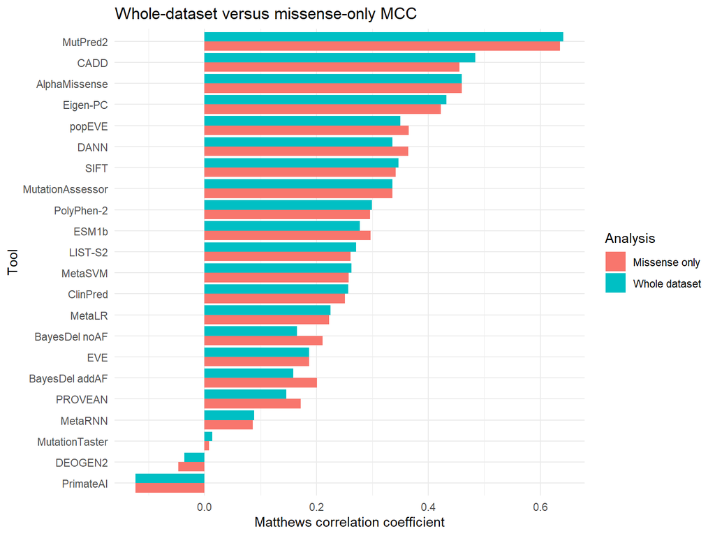

```r
whole_vs_missense_performance_comparison %>%
  filter(!is.na(whole_dataset_mcc), !is.na(missense_mcc)) %>%
  select(tool, whole_dataset_mcc, missense_mcc) %>%
  tidyr::pivot_longer(
    cols = c(whole_dataset_mcc, missense_mcc),
    names_to = "analysis_type",
    values_to = "mcc"
  ) %>%
  mutate(
    analysis_type = dplyr::recode(
      analysis_type,
      whole_dataset_mcc = "Whole dataset",
      missense_mcc = "Missense only"
    )
  ) %>%
  ggplot(aes(x = mcc, y = reorder(tool, mcc), fill = analysis_type)) +
  geom_col(position = "dodge") +
  labs(
    title = "Whole-dataset versus missense-only MCC",
    x = "Matthews correlation coefficient",
    y = "Tool",
    fill = "Analysis"
  ) +
  theme_minimal()
```

##splice tools focused analysis

## splice tool coverage and score summary table

```r
SPLICE_FOCUSED_DATASET <- ANALYSIS_DATASET_WITH_VARIANT_GROUPS %>%
  filter(variant_group_splice)

SPLICE_FOCUSED_DATASET %>%
  summarise(
    total_splice_variants = n(),
    pathogenic = sum(observed_binary == "Pathogenic", na.rm = TRUE),
    benign = sum(observed_binary == "Benign", na.rm = TRUE),
    vus_or_other = sum(!observed_binary %in% c("Pathogenic", "Benign") | is.na(observed_binary)))
```

```
## # A tibble: 1 × 4
##   total_splice_variants pathogenic benign vus_or_other
##                   <int>      <int>  <int>        <int>
## 1                   127        101      3           23
```

##splice tool coverage summary

```r
splice_tool_coverage_summary <- raw_score_coverage_by_tool_and_variant_group %>%
  filter(
    variant_group == "Splice / cryptic splice",
    tool %in% c(
      "SpliceAI",
      "SpliceAI acceptor gain",
      "SpliceAI acceptor loss",
      "SpliceAI donor gain",
      "SpliceAI donor loss",
      "MaxEntScan",
      "ada_score",
      "rf_score"
    )
  ) %>%
  arrange(desc(percent_with_score))

splice_tool_coverage_summary %>%
  print(n = Inf, width = Inf)
```

```
## # A tibble: 8 × 8
##   variant_group           tool                   tool_classification
##   <chr>                   <chr>                  <chr>
## 1 Splice / cryptic splice SpliceAI acceptor gain Splicing predictor
## 2 Splice / cryptic splice SpliceAI acceptor loss Splicing predictor
## 3 Splice / cryptic splice SpliceAI donor gain    Splicing predictor
## 4 Splice / cryptic splice SpliceAI donor loss    Splicing predictor
## 5 Splice / cryptic splice SpliceAI               Splicing predictor
## 6 Splice / cryptic splice MaxEntScan             Splicing predictor
## 7 Splice / cryptic splice ada_score              Splicing predictor
## 8 Splice / cryptic splice rf_score               Splicing predictor
##   score_column            total_variants_in_group variants_with_score
##   <chr>                                     <int>               <int>
## 1 SpliceAI_pred_DS_AG_new                     127                 116
## 2 SpliceAI_pred_DS_AL_new                     127                 116
```

[output cut: 16 more lines]

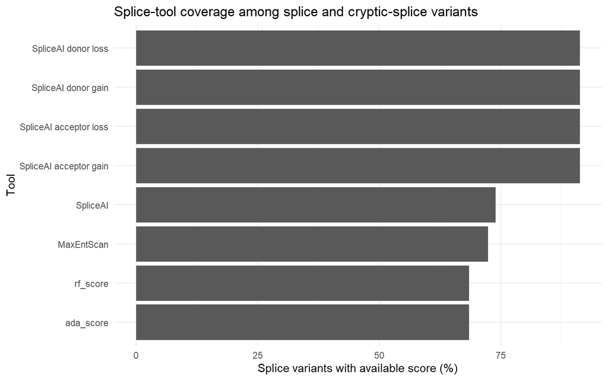

```r
splice_tool_coverage_summary %>%
  arrange(percent_with_score) %>%
  ggplot(aes(x = percent_with_score, y = reorder(tool, percent_with_score))) +
  geom_col() +
  labs(
    title = "Splice-tool coverage among splice and cryptic-splice variants",
    x = "Splice variants with available score (%)",
    y = "Tool"
  ) +
  theme_minimal()
```